# Data Analysis Skill Test - Analyst Regional Economics

# **Case 2**

##### - Read data_comexstat.csv file

```r
data_comexstat <- read_csv("C:/Users/rezen/OneDrive/Documentos/4intelligence/data_comexstat.csv")
```

##### 1. Evolution of total monthly and total annual exports from Brazil of ‘soybeans’, ‘soybean oil’ and ‘soybean meal’:

##### **Brazil Total Monthly Exports**

##### - Brazil Exports Monthly data in TONS:

```r
mes=c("01","02","03","04","05","06","07","08","09","10","11","12")
year = seq(1997, 2019, 1)
year = as.character(year)


states = data_comexstat$state
states = unique(states)
states = sort(states)
states
```

```
##  [1] "AC" "AL" "AM" "AP" "BA" "CE" "DF" "ES" "GO" "MA" "MG" "MS" "MT" "PA" "PB"
## [16] "PE" "PI" "PR" "RJ" "RN" "RO" "RR" "RS" "SC" "SE" "SP" "TO"
```

```r
products = data_comexstat$product
products = unique(products)
products = sort(products)
products
```

```
## [1] "corn"         "soybean_meal" "soybean_oil"  "soybeans"     "sugar"
## [6] "wheat"
```

```r
list_comex_br_product = list()
list_comex_br = list()
for (k in 1:length(products)) {

  for (j in 1:length(year)) {
    for (i in 1:length(mes)) {
      list_comex_br_product[[i+(length(mes)*(j-1))]] = data_comexstat %>%
        select(date, product, state, country, type, route, tons, usd) %>%
        filter(date==paste(year[j], mes[i], "01", sep="-"), product==products[k], type=='Export')
    }
  }
  list_comex_br[[k]]=list_comex_br_product
}


export_br = list()
for (j in 1:length(products)) {
  export_br_aux = data.frame()
  x = list_comex_br[[j]]
  for (i in 1:length(list_comex_br[[j]])) {
    export_br_aux = rbind(export_br_aux, sum(x[[i]]$tons))
  }
  export_br[[j]]=export_br_aux
}


data_export = data.frame()
for (j in 1:length(year)) {
  for (i in  1:length(mes)) {
    data_export = rbind(data_export, paste(year[j], mes[i], "01", sep="-"))
  }
}


for (i in 1:length(products)) {
  export_br[[i]] = cbind(data_export, export_br[[i]])
  export_br[[i]] = cbind(export_br[[i]], rep(products[i],276))
  colnames(export_br[[i]]) = c("date","sum_tons","product")
  export_br[[i]]$date = as.Date(export_br[[i]]$date)
}
```

##### - Brazil Total Monthly Exports of Soybeans in TONS

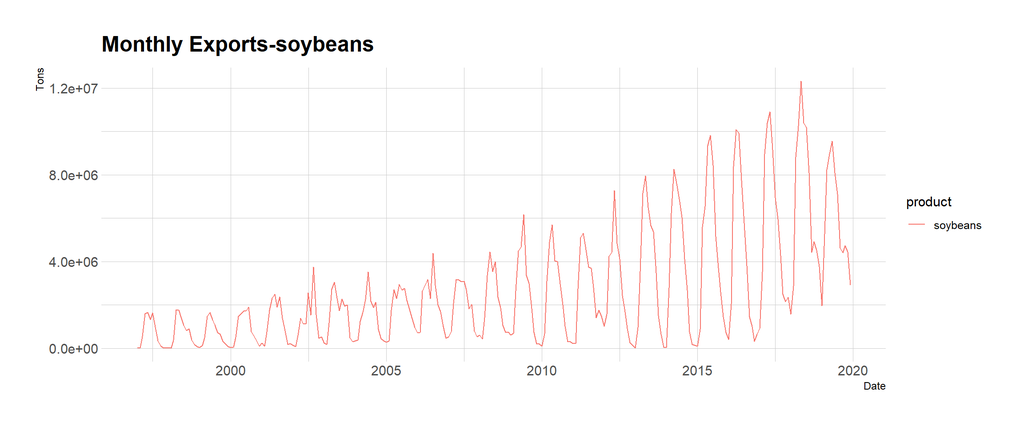

```r
grap_soybeans_br = ggplot(export_br[[4]], aes(x=date, y=sum_tons, color=product))+
  geom_line()+
  theme_ipsum()+
  ggtitle(paste("Monthly Exports", products[4], sep="-"))+
  xlab("Date")+
  ylab("Tons")
grap_soybeans_br
```

##### - Brazil Total Monthly Exports of Soybean_oil in TONS

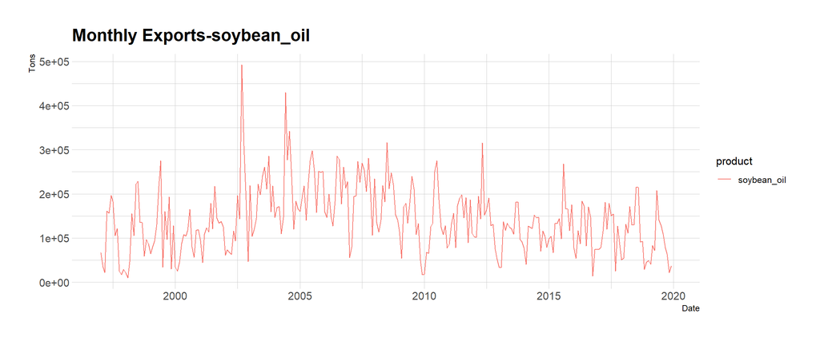

```r
grap_s_oil_br = ggplot(export_br[[3]], aes(x=date, y=sum_tons, color=product))+
  geom_line()+
  theme_ipsum()+
  ggtitle(paste("Monthly Exports", products[3], sep="-"))+
  xlab("Date")+
  ylab("Tons")
grap_s_oil_br
```

##### - Brazil Total Monthly Exports of Soybean_meal in TONS

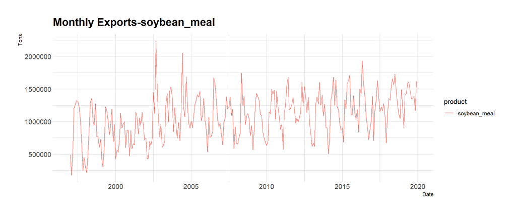

```r
grap_s_meal_br = ggplot(export_br[[2]], aes(x=date, y=sum_tons, color=product))+
  geom_line()+
  theme_ipsum()+
  ggtitle(paste("Monthly Exports", products[2], sep="-"))+
  xlab("Date")+
  ylab("Tons")
grap_s_meal_br
```

##### - Brazil Exports Monthly data in USD:

```r
export_br_usd = list()
for (j in 1:length(products)) {
  export_br_aux_usd = data.frame()
  x = list_comex_br[[j]]
  for (i in 1:length(list_comex_br[[j]])) {
    export_br_aux_usd = rbind(export_br_aux_usd, sum(x[[i]]$usd))
  }
  export_br_usd[[j]]=export_br_aux_usd
}


for (i in 1:length(products)) {
  export_br_usd[[i]] = cbind(data_export, export_br_usd[[i]])
  export_br_usd[[i]] = cbind(export_br_usd[[i]], rep(products[i],276))
  colnames(export_br_usd[[i]]) = c("date","sum_usd","product")
  export_br_usd[[i]]$date = as.Date(export_br_usd[[i]]$date)
}
```

##### - Brazil Total Monthly Exports of Soybeans in USD

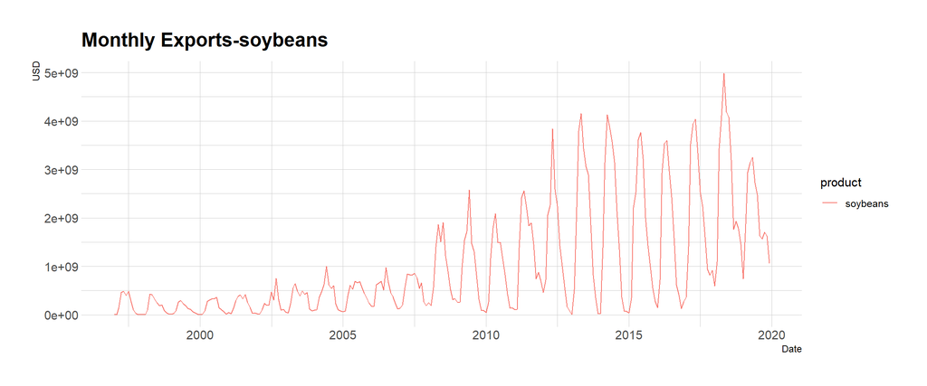

```r
grap_soybeans_br = ggplot(export_br_usd[[4]], aes(x=date, y=sum_usd, color=product))+
  geom_line()+
  theme_ipsum()+
  ggtitle(paste("Monthly Exports", products[4], sep="-"))+
  xlab("Date")+
  ylab("USD")
grap_soybeans_br
```

##### - Brazil Total Monthly Exports of Soybean_oil in USD

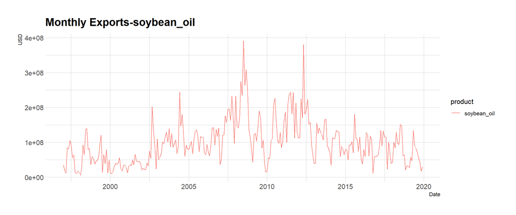

```r
grap_s_oil_br = ggplot(export_br_usd[[3]], aes(x=date, y=sum_usd, color=product))+
  geom_line()+
  theme_ipsum()+
  ggtitle(paste("Monthly Exports", products[3], sep="-"))+
  xlab("Date")+
  ylab("USD")
grap_s_oil_br
```

##### - Brazil Total Monthly Exports of Soybean_meal in USD

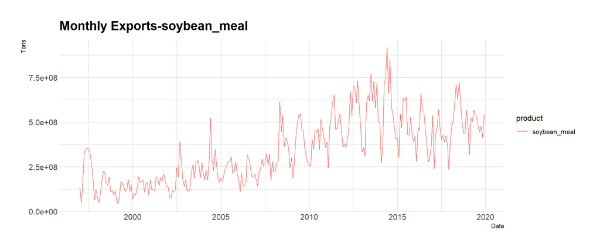

```r
grap_s_meal_br = ggplot(export_br_usd[[2]], aes(x=date, y=sum_usd, color=product))+
  geom_line()+
  theme_ipsum()+
  ggtitle(paste("Monthly Exports", products[2], sep="-"))+
  xlab("Date")+
  ylab("Tons")
grap_s_meal_br
```

##### **Brazil Total Annual Exports**

##### - Brazil Annual Export Data in TONS

```r
products_year_tons = data.frame()
for (j in 1:6) {
  for (i in 1:23) {
    products_year_tons[i,j] = sum(export_br[[j]]$sum_tons[(12*(i-1)+1):(i*12)])
  }
}
colnames(products_year_tons) = paste(products, "_tons")
```

##### - Brazil Annual Export Data in USD

```r
products_year_usd = data.frame()
for (j in 1:6) {
  for (i in 1:23) {
    products_year_usd[i,j] = sum(export_br_usd[[j]]$sum_usd[(12*(i-1)+1):(i*12)])
  }
}

colnames(products_year_usd) = paste(products,"_usd")
```

##### - Brazil Annual Export Data in TONS and USD

```r
data_year = cbind(year,products_year_tons, products_year_usd)
```

##### - Brazil Total Annual Exports of Soybeans in TONS

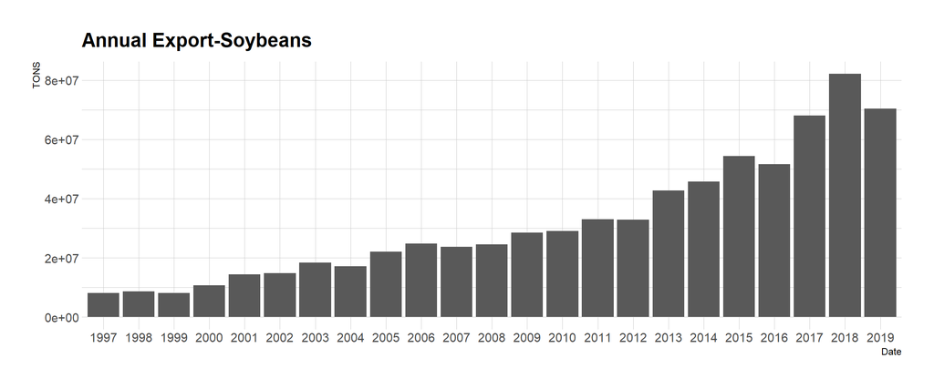

```r
grap_soy_annual_br = ggplot(data_year, aes(x=year, y=`soybeans _tons`))+
  geom_bar(stat = "identity")+
  theme_ipsum()+
  ggtitle(paste("Annual Export", "Soybeans ", sep="-"))+
  xlab("Date")+
  ylab("TONS")
grap_soy_annual_br
```

##### - Brazil Total Annual Exports of Soybean_oil in TONS

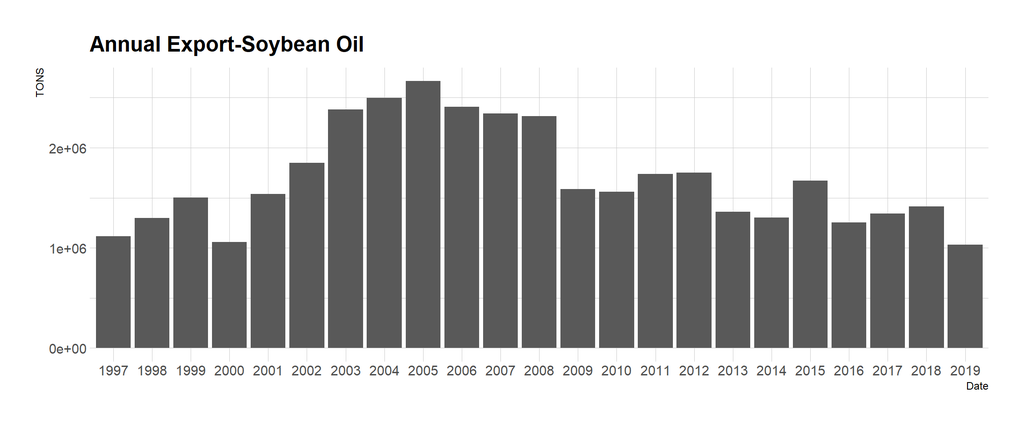

```r
grap_s_oil_annual_br = ggplot(data_year, aes(x=year, y=`soybean_oil _tons`))+
  geom_bar(stat = "identity")+
  theme_ipsum()+
  ggtitle(paste("Annual Export", "Soybean Oil", sep="-"))+
  xlab("Date")+
  ylab("TONS")
grap_s_oil_annual_br
```

##### - Brazil Total Annual Exports of Soybean_meal in TONS

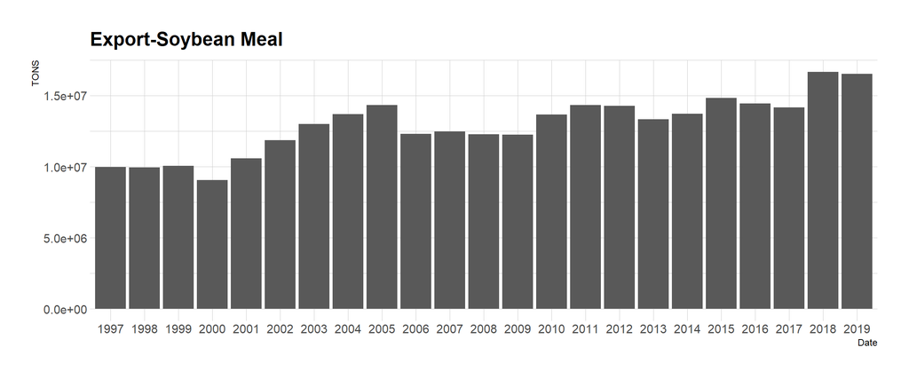

```r
grap_s_meal_annual_br = ggplot(data_year, aes(x=year, y=`soybean_meal _tons`))+
  geom_bar(stat = "identity")+
  theme_ipsum()+
  ggtitle(paste("Export", "Soybean Meal", sep="-"))+
  xlab("Date")+
  ylab("TONS")
grap_s_meal_annual_br
```

##### 2. What are the 3 most important products exported by Brazil in the last 5 years?

##### - Filter the Data - 2015 to 2019 - TONS

```r
products_2015_2019 = list()
for (i in 1:6) {
  products_2015_2019[[i]] = export_br[[i]] %>%
    select(date, sum_tons, product) %>%
    filter(date>="2015-01-01")
}
```

##### - Filter the Data - 2015 to 2019 - USD

```r
products_2015_2019_usd = list()
for (i in 1:6) {
  products_2015_2019_usd[[i]] = export_br_usd[[i]] %>%
    select(date, sum_usd, product) %>%
    filter(date>="2015-01-01")
}
```

##### **2015**

##### - Total 2015 Exports Brazil - TONS

```r
products_2015 = list()
for (i in 1:6) {
  products_2015[[i]] = products_2015_2019[[i]] %>%
    select(date, sum_tons, product) %>%
    filter(date<="2015-12-01")
}
sum_products_2015 = data.frame()
for (i in 1:6) {
  sum_products_2015 = rbind(sum_products_2015, sum(products_2015[[i]]$sum_tons))
}
colnames(sum_products_2015)=c("Export_TONS")
sum_products_2015 = cbind(sum_products_2015, products)
sum_products_2015
```

```
##   Export_TONS     products
## 1    28900377         corn
## 2    14826596 soybean_meal
## 3     1669874  soybean_oil
## 4    54303484     soybeans
## 5    23809476        sugar
## 6     1778870        wheat
```

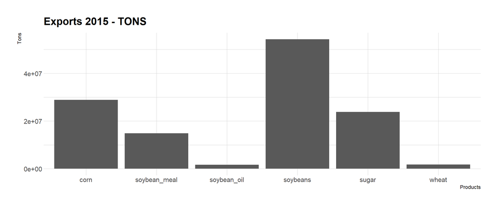

```r
graph_2015 = ggplot(sum_products_2015, aes(x=products, y=Export_TONS))+
  geom_bar(stat = "identity")+
  theme_ipsum()+
  ggtitle("Exports 2015 - TONS")+
  xlab("Products")+
  ylab("Tons")
graph_2015
```

##### - Total 2015 Exports Brazil - USD

```r
products_2015_usd = list()
for (i in 1:6) {
  products_2015_usd[[i]] = products_2015_2019_usd[[i]] %>%
    select(date, sum_usd, product) %>%
    filter(date<="2015-12-01")
}
sum_products_2015_usd = data.frame()
for (i in 1:6) {
  sum_products_2015_usd = rbind(sum_products_2015_usd, sum(products_2015_usd[[i]]$sum_usd))
}
colnames(sum_products_2015_usd)=c("Export_USD")
sum_products_2015_usd = cbind(sum_products_2015_usd, products)
sum_products_2015_usd
```

```
##    Export_USD     products
## 1  5002188893         corn
## 2  5821009079 soybean_meal
## 3  1153974925  soybean_oil
## 4 20975672739     soybeans
## 5  7569995882        sugar
## 6   353335814        wheat
```

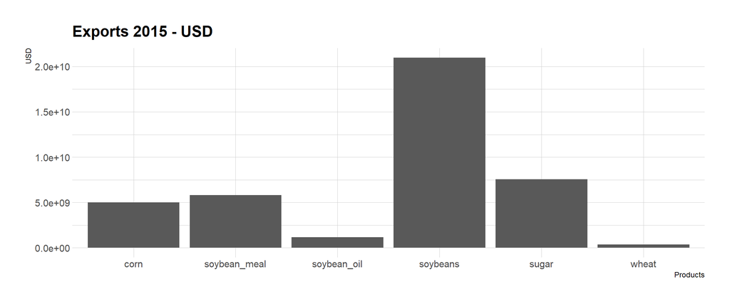

```r
graph_2015_usd = ggplot(sum_products_2015_usd, aes(x=products, y=Export_USD))+
  geom_bar(stat = "identity")+
  theme_ipsum()+
  ggtitle("Exports 2015 - USD")+
  xlab("Products")+
  ylab("USD")
graph_2015_usd
```

##### **2016**

##### - Total 2016 Exports Brazil - TONS

```r
products_2016 = list()
for (i in 1:6) {
  products_2016[[i]] = products_2015_2019[[i]] %>%
    select(date, sum_tons, product) %>%
    filter(date>="2016-01-01", date<="2016-12-01")
}
sum_products_2016 = data.frame()
for (i in 1:6) {
  sum_products_2016 = rbind(sum_products_2016, sum(products_2016[[i]]$sum_tons))
}
colnames(sum_products_2016)=c("Export_TONS")
sum_products_2016 = cbind(sum_products_2016, products)
sum_products_2016
```

```
##   Export_TONS     products
## 1  21864440.9         corn
## 2  14443791.5 soybean_meal
## 3   1253542.3  soybean_oil
## 4  51573806.9     soybeans
## 5  28806952.1        sugar
## 6    713326.2        wheat
```

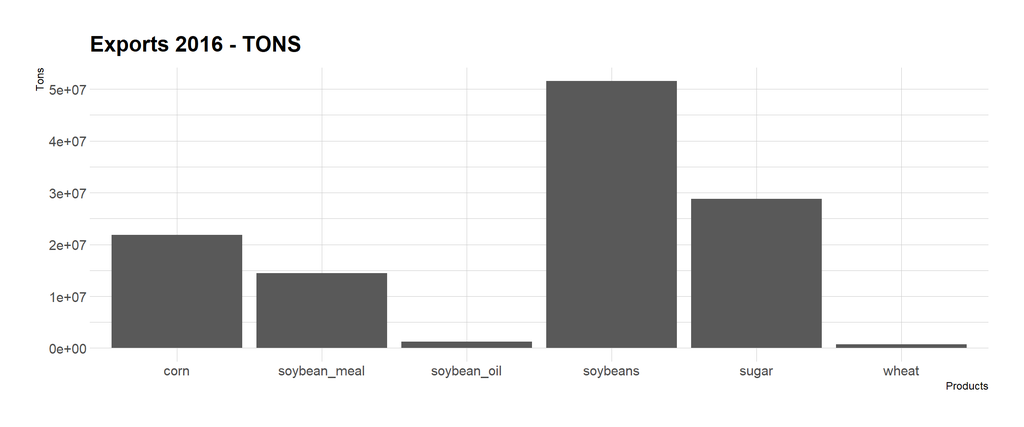

```r
graph_2016 = ggplot(sum_products_2016, aes(x=products, y=Export_TONS))+
  geom_bar(stat = "identity")+
  theme_ipsum()+
  ggtitle("Exports 2016 - TONS")+
  xlab("Products")+
  ylab("Tons")
graph_2016
```

In, the main product exported was soybeans (51 million tons), the second product most exported was sugar (28 million tons), followed by corn (21 million tons). The commodity less exported was wheat, with 713 thousand tons.

##### - Total 2016 Exports Brazil - USD

```r
products_2016_usd = list()
for (i in 1:6) {
  products_2016_usd[[i]] = products_2015_2019_usd[[i]] %>%
    select(date, sum_usd, product) %>%
    filter(date>="2016-01-01", date<="2016-12-01")
}
sum_products_2016_usd = data.frame()
for (i in 1:6) {
  sum_products_2016_usd = rbind(sum_products_2016_usd, sum(products_2016_usd[[i]]$sum_usd))
}
colnames(sum_products_2016_usd)=c("Export_USD")
sum_products_2016_usd = cbind(sum_products_2016_usd, products)
sum_products_2016_usd
```

```
##    Export_USD     products
## 1  3736202055         corn
## 2  5192780725 soybean_meal
## 3   897518331  soybean_oil
## 4 19328432149     soybeans
## 5 10388133806        sugar
## 6   115392534        wheat
```

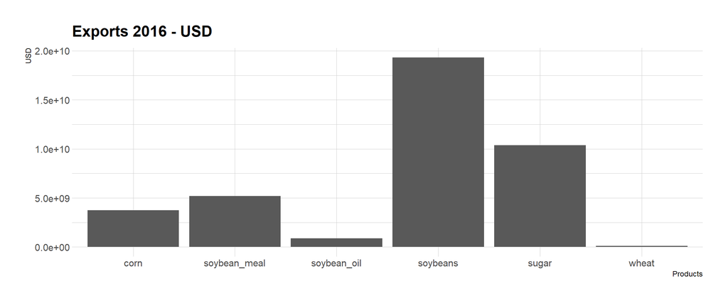

```r
graph_2016_usd = ggplot(sum_products_2016_usd, aes(x=products, y=Export_USD))+
  geom_bar(stat = "identity")+
  theme_ipsum()+
  ggtitle("Exports 2016 - USD")+
  xlab("Products")+
  ylab("USD")
graph_2016_usd
```

##### **2017**

##### Total 2017 Exports Brazil - TONS

```r
products_2017 = list()
for (i in 1:6) {
  products_2017[[i]] = products_2015_2019[[i]] %>%
    select(date, sum_tons, product) %>%
    filter(date>="2017-01-01", date<="2017-12-01")
}
sum_products_2017 = data.frame()
for (i in 1:6) {
  sum_products_2017 = rbind(sum_products_2017, sum(products_2017[[i]]$sum_tons))
}
colnames(sum_products_2017)=c("Export_TONS")
sum_products_2017 = cbind(sum_products_2017, products)
sum_products_2017
```

```
##   Export_TONS     products
## 1  29255329.9         corn
## 2  14176743.7 soybean_meal
## 3   1342365.4  soybean_oil
## 4  68006593.1     soybeans
## 5  28614225.6        sugar
## 6    617664.4        wheat
```

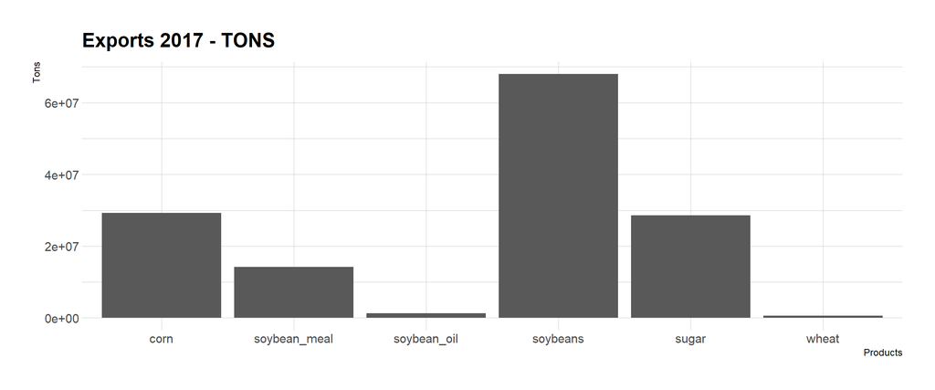

```r
graph_2017 = ggplot(sum_products_2017, aes(x=products, y=Export_TONS))+
  geom_bar(stat = "identity")+
  theme_ipsum()+
  ggtitle("Exports 2017 - TONS")+
  xlab("Products")+
  ylab("Tons")
graph_2017
```

##### - Total 2017 Exports Brazil - USD

```r
products_2017_usd = list()
for (i in 1:6) {
  products_2017_usd[[i]] = products_2015_2019_usd[[i]] %>%
    select(date, sum_usd, product) %>%
    filter(date>="2017-01-01", date<="2017-12-01")
}
sum_products_2017_usd = data.frame()
for (i in 1:6) {
  sum_products_2017_usd = rbind(sum_products_2017_usd, sum(products_2017_usd[[i]]$sum_usd))
}
colnames(sum_products_2017_usd)=c("Export_USD")
sum_products_2017_usd = cbind(sum_products_2017_usd, products)
sum_products_2017_usd
```

```
##    Export_USD     products
## 1  4628510219         corn
## 2  4973223446 soybean_meal
## 3  1030942099  soybean_oil
## 4 25662801909     soybeans
## 5 11374586847        sugar
## 6   102835660        wheat
```

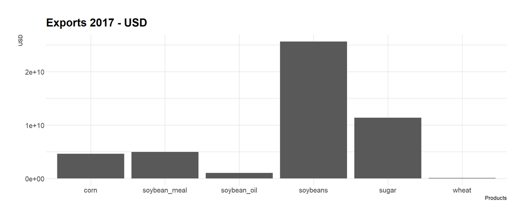

```r
graph_2017_usd = ggplot(sum_products_2017_usd, aes(x=products, y=Export_USD))+
  geom_bar(stat = "identity")+
  theme_ipsum()+
  ggtitle("Exports 2017 - USD")+
  xlab("Products")+
  ylab("USD")
graph_2017_usd
```

In 2017, the exports in USD were very similar wiht the exports in 2015 and 2016. soybeans was the most product exported, followed by the sugar and soybean meal. The exported values of corn and soybean meal were very close.

##### **2018**

##### - Total 2018 Exports Brazil - TONS

```r
products_2018 = list()
for (i in 1:6) {
  products_2018[[i]] = products_2015_2019[[i]] %>%
    select(date, sum_tons, product) %>%
    filter(date>="2018-01-01", date<="2018-12-01")
}
sum_products_2018 = data.frame()
for (i in 1:6) {
  sum_products_2018 = rbind(sum_products_2018, sum(products_2018[[i]]$sum_tons))
}
colnames(sum_products_2018)=c("Export_TONS")
sum_products_2018 = cbind(sum_products_2018, products)
sum_products_2018
```

```
##   Export_TONS     products
## 1  22747267.9         corn
## 2  16669975.8 soybean_meal
## 3   1414356.1  soybean_oil
## 4  82147435.8     soybeans
## 5  21144879.5        sugar
## 6    221278.5        wheat
```

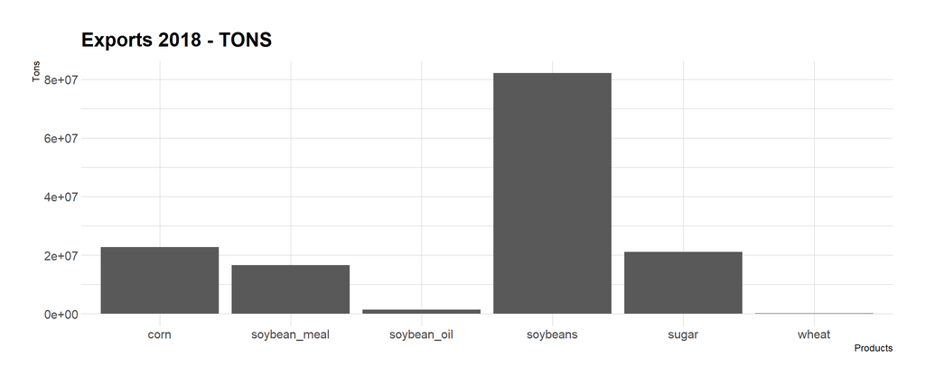

```r
graph_2018 = ggplot(sum_products_2018, aes(x=products, y=Export_TONS))+
  geom_bar(stat = "identity")+
  theme_ipsum()+
  ggtitle("Exports 2018 - TONS")+
  xlab("Products")+
  ylab("Tons")
graph_2018
```

In 2018, the three most important commodity were soybeans, corn and sugar.

##### - Total 2018 Exports Brazil - USD

```r
products_2018_usd = list()
for (i in 1:6) {
  products_2018_usd[[i]] = products_2015_2019_usd[[i]] %>%
    select(date, sum_usd, product) %>%
    filter(date>="2018-01-01", date<="2018-12-01")
}
sum_products_2018_usd = data.frame()
for (i in 1:6) {
  sum_products_2018_usd = rbind(sum_products_2018_usd, sum(products_2018_usd[[i]]$sum_usd))
}
colnames(sum_products_2018_usd)=c("Export_USD")
sum_products_2018_usd = cbind(sum_products_2018_usd, products)
sum_products_2018_usd
```

```
##    Export_USD     products
## 1  3956254222         corn
## 2  6624036364 soybean_meal
## 3  1025231907  soybean_oil
## 4 32619856907     soybeans
## 5  6490856103        sugar
## 6    40527570        wheat
```

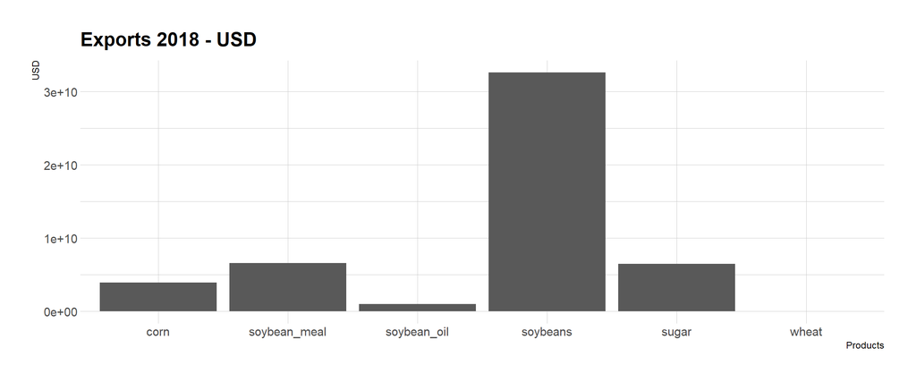

```r
graph_2018_usd = ggplot(sum_products_2018_usd, aes(x=products, y=Export_USD))+
  geom_bar(stat = "identity")+
  theme_ipsum()+
  ggtitle("Exports 2018 - USD")+
  xlab("Products")+
  ylab("USD")
graph_2018_usd
```

In monetary values, USD, soybean was again the best-selling product in 2018. In this year, soybean meal was the second product exported, with the sugar in third place.

##### **2019**

##### - Total 2019 Exports Brazil - TONS

```r
products_2019 = list()
for (i in 1:6) {
  products_2019[[i]] = products_2015_2019[[i]] %>%
    select(date, sum_tons, product) %>%
    filter(date>="2019-01-01", date<="2019-12-01")
}
sum_products_2019 = data.frame()
for (i in 1:6) {
  sum_products_2019 = rbind(sum_products_2019, sum(products_2019[[i]]$sum_tons))
}
colnames(sum_products_2019)=c("Export_TONS")
sum_products_2019 = cbind(sum_products_2019, products)
sum_products_2019
```

```
##   Export_TONS     products
## 1  41831922.7         corn
## 2  16530380.8 soybean_meal
## 3   1031289.6  soybean_oil
## 4  70300144.7     soybeans
## 5  17658116.0        sugar
## 6    554696.6        wheat
```

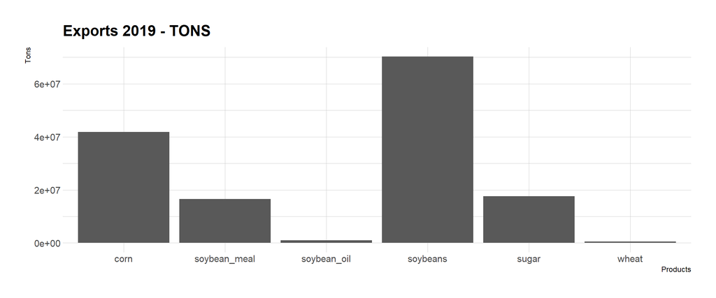

```r
graph_2019 = ggplot(sum_products_2019, aes(x=products, y=Export_TONS))+
  geom_bar(stat = "identity")+
  theme_ipsum()+
  ggtitle("Exports 2019 - TONS")+
  xlab("Products")+
  ylab("Tons")
graph_2019
```

In 2019, soybeans exports were over 70 million tons. The second product most exported was corn and the third was sugar.

##### - Total 2019 Exports Brazil - USD

```r
products_2019_usd = list()
for (i in 1:6) {
  products_2019_usd[[i]] = products_2015_2019_usd[[i]] %>%
    select(date, sum_usd, product) %>%
    filter(date>="2019-01-01", date<="2019-12-01")
}
sum_products_2019_usd = data.frame()
for (i in 1:6) {
  sum_products_2019_usd = rbind(sum_products_2019_usd, sum(products_2019_usd[[i]]$sum_usd))
}
colnames(sum_products_2019_usd)=c("Export_USD")
sum_products_2019_usd = cbind(sum_products_2019_usd, products)
sum_products_2019_usd
```

```
##    Export_USD     products
## 1  7124565521         corn
## 2  5796673823 soybean_meal
## 3   688279611  soybean_oil
## 4 24738766153     soybeans
## 5  5114913383        sugar
## 6   114853808        wheat
```

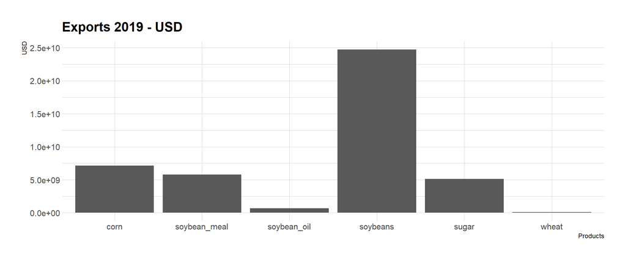

```r
graph_2019_usd = ggplot(sum_products_2019_usd, aes(x=products, y=Export_USD))+
  geom_bar(stat = "identity")+
  theme_ipsum()+
  ggtitle("Exports 2019 - USD")+
  xlab("Products")+
  ylab("USD")
graph_2019_usd
```

In 2019, corn was the second most import product exported by Brazil in both tons and dollars. But, the most commodity exported was soybeans, as the previously years. SOybean meal was the third product most sold by Brazil.

##### **EXPORTS 2015-2019**

##### - Total 2015-2019 Exports Brazil - TONS

```r
sum_products_total = data.frame()
for (i in 1:6) {
  sum_products_total = rbind(sum_products_total, sum(products_2015_2019[[i]]$sum_tons))
}

colnames(sum_products_total)=c("Export_TONS")
sum_products_total = cbind(sum_products_total, products)
sum_products_total
```

```
##   Export_TONS     products
## 1   144599338         corn
## 2    76647488 soybean_meal
## 3     6711428  soybean_oil
## 4   326331464     soybeans
## 5   120033649        sugar
## 6     3885836        wheat
```

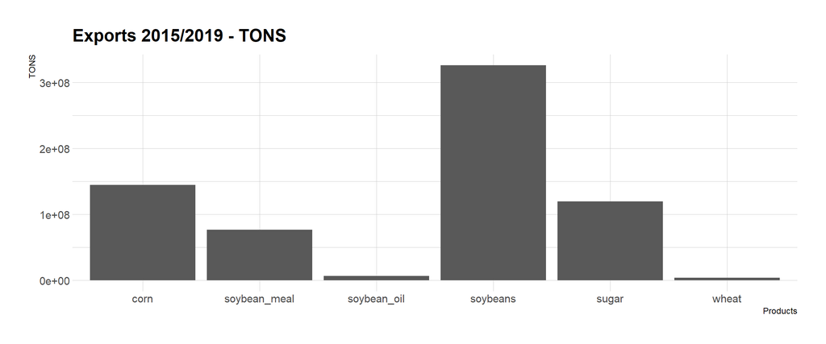

```r
graph_total = ggplot(sum_products_total, aes(x=products, y=Export_TONS))+
  geom_bar(stat = "identity")+
  theme_ipsum()+
  ggtitle("Exports 2015/2019 - TONS")+
  xlab("Products")+
  ylab("TONS")
graph_total
```

Analyzing the entire period,2015 to 2019, the three most important products exported by Brazil in tons was, soybeans, corn and sugar.

##### - Total 2015-2019 Exports Brazil - USD

```r
sum_products_total_usd = data.frame()
for (i in 1:6) {
  sum_products_total_usd = rbind(sum_products_total_usd, sum(products_2015_2019_usd[[i]]$sum_usd))
}

colnames(sum_products_total_usd)=c("Export_USD")
sum_products_total_usd = cbind(sum_products_total_usd, products)
sum_products_total_usd
```

```
##     Export_USD     products
## 1  24447720910         corn
## 2  28407723437 soybean_meal
## 3   4795946873  soybean_oil
## 4 123325529857     soybeans
## 5  40938486021        sugar
## 6    726945386        wheat
```

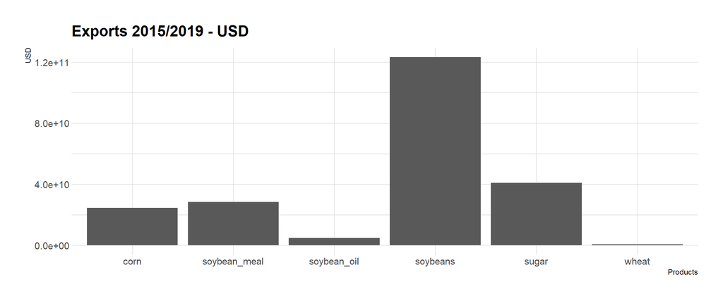

```r
graph_total_usd = ggplot(sum_products_total_usd, aes(x=products, y=Export_USD))+
  geom_bar(stat = "identity")+
  theme_ipsum()+
  ggtitle("Exports 2015/2019 - USD")+
  xlab("Products")+
  ylab("USD")
graph_total_usd
```

Analyzing exports between 2015 and 2019, in dollars, soybean remains the most important product exported by Brazil. Sugar is in second place, followed by the soybean meal.

##### 3. What are the main routes through which Brazil have been exporting ‘corn’ in the last few years? Are there differences in the relative importancem of routes depending on the product?

##### - Routes data

```r
routes = data_comexstat$route
routes = unique(routes)
routes = sort(routes)
routes
```

```
## [1] "Air"    "Ground" "Other"  "River"  "Sea"
```

##### - Exports products by Route

```r
##### Corn
list_comex_br_route_total = list()
list_comex_br_route = list()
for (k in 1:length(routes)) {

  for (j in 1:length(year)) {
    for (i in 1:length(mes)) {
      list_comex_br_route_total[[i+(length(mes)*(j-1))]] = data_comexstat %>%
        select(date, product, state, country, type, route, tons, usd) %>%
        filter(date==paste(year[j], mes[i], "01", sep="-"), route==routes[k], product=="corn", type=='Export')
    }
  }
  list_comex_br_route[[k]]=list_comex_br_route_total
}
                                                                                                                                                                                                                                                                                                                                                            ##### Soybean_meal
list_meal_br_route_total = list()
list_meal_br_route = list()
for (k in 1:length(routes)) {

  for (j in 1:length(year)) {
    for (i in 1:length(mes)) {
      list_meal_br_route_total[[i+(length(mes)*(j-1))]] = data_comexstat %>%
        select(date, product, state, country, type, route, tons, usd) %>%
        filter(date==paste(year[j], mes[i], "01", sep="-"), route==routes[k], product=="soybean_meal", type=='Export')
    }
  }
  list_meal_br_route[[k]]=list_meal_br_route_total
}

                                                                                                                                                                                                                                                                                                                                                            ##### Soybean_oil
list_oil_br_route_total = list()
list_oil_br_route = list()
for (k in 1:length(routes)) {

  for (j in 1:length(year)) {
    for (i in 1:length(mes)) {
      list_oil_br_route_total[[i+(length(mes)*(j-1))]] = data_comexstat %>%
        select(date, product, state, country, type, route, tons, usd) %>%
        filter(date==paste(year[j], mes[i], "01", sep="-"), route==routes[k], product=="soybean_oil", type=='Export')
    }
  }
  list_oil_br_route[[k]]=list_oil_br_route_total
}

##### Soybeans
list_soy_br_route_total = list()
list_soy_br_route = list()
for (k in 1:length(routes)) {

  for (j in 1:length(year)) {
    for (i in 1:length(mes)) {
      list_soy_br_route_total[[i+(length(mes)*(j-1))]] = data_comexstat %>%
        select(date, product, state, country, type, route, tons, usd) %>%
        filter(date==paste(year[j], mes[i], "01", sep="-"), route==routes[k], product=="soybeans", type=='Export')
    }
  }
  list_soy_br_route[[k]]=list_soy_br_route_total
}


##### Sugar
list_sugar_br_route_total = list()
list_sugar_br_route = list()
for (k in 1:length(routes)) {

  for (j in 1:length(year)) {
    for (i in 1:length(mes)) {
      list_sugar_br_route_total[[i+(length(mes)*(j-1))]] = data_comexstat %>%
        select(date, product, state, country, type, route, tons, usd) %>%
        filter(date==paste(year[j], mes[i], "01", sep="-"), route==routes[k], product=="sugar", type=='Export')
    }
  }
  list_sugar_br_route[[k]]=list_sugar_br_route_total
}


##### Wheat
list_wheat_br_route_total = list()
list_wheat_br_route = list()
for (k in 1:length(routes)) {

  for (j in 1:length(year)) {
    for (i in 1:length(mes)) {
      list_wheat_br_route_total[[i+(length(mes)*(j-1))]] = data_comexstat %>%
        select(date, product, state, country, type, route, tons, usd) %>%
        filter(date==paste(year[j], mes[i], "01", sep="-"), route==routes[k], product=="wheat", type=='Export')
    }
  }
  list_wheat_br_route[[k]]=list_wheat_br_route_total
}
```

##### - TONS

```r
##### Corn
export_br = list()
export_br_route_corn = list()
for (j in 1:length(routes)) {
  export_br_route_aux = data.frame()
  x = list_comex_br_route[[j]]
  for (i in 1:length(list_comex_br_route[[j]])) {
    export_br_route_aux = rbind(export_br_route_aux, sum(x[[i]]$tons))
  }
  export_br_route_corn[[j]]=export_br_route_aux
}


data_export = data.frame()
for (j in 1:length(year)) {
  for (i in  1:length(mes)) {
    data_export = rbind(data_export, paste(year[j], mes[i], "01", sep="-"))
  }
}


for (i in 1:length(routes)) {
  export_br_route_corn[[i]] = cbind(data_export, export_br_route_corn[[i]])
  export_br_route_corn[[i]] = cbind(export_br_route_corn[[i]], rep(routes[i],276))
  colnames(export_br_route_corn[[i]]) = c("date","sum_tons","routes")
  export_br_route_corn[[i]]$date = as.Date(export_br_route_corn[[i]]$date)
}


routes_2015_2019_ton = list()
for (i in 1:5) {
  routes_2015_2019_ton[[i]] = export_br_route_corn[[i]] %>%
    select(date, sum_tons, routes) %>%
    filter(date>="2015-01-01")
}




## Soybean_meal
export_br = list()
export_br_route_meal = list()
for (j in 1:length(routes)) {
  export_br_route_meal_aux = data.frame()
  x = list_comex_br_route[[j]]
  for (i in 1:length(list_meal_br_route[[j]])) {
    export_br_route_meal_aux = rbind(export_br_route_meal_aux, sum(x[[i]]$tons))
  }
  export_br_route_meal[[j]]=export_br_route_meal_aux
}


data_export = data.frame()
for (j in 1:length(year)) {
  for (i in  1:length(mes)) {
    data_export = rbind(data_export, paste(year[j], mes[i], "01", sep="-"))
  }
}


for (i in 1:length(routes)) {
  export_br_route_meal[[i]] = cbind(data_export, export_br_route_meal[[i]])
  export_br_route_meal[[i]] = cbind(export_br_route_corn[[i]], rep(routes[i],276))
  colnames(export_br_route_meal[[i]]) = c("date","sum_tons","routes")
  export_br_route_meal[[i]]$date = as.Date(export_br_route_meal[[i]]$date)
}


routes_2015_2019_ton_meal = list()
for (i in 1:5) {
  routes_2015_2019_ton_meal[[i]] = export_br_route_meal[[i]] %>%
    select(date, sum_tons, routes) %>%
    filter(date>="2015-01-01")
}




##### Soybean_oil
export_br = list()
export_br_route_oil = list()
for (j in 1:length(routes)) {
  export_br_route_oil_aux = data.frame()
  x = list_oil_br_route[[j]]
  for (i in 1:length(list_comex_br_route[[j]])) {
    export_br_route_oil_aux = rbind(export_br_route_oil_aux, sum(x[[i]]$tons))
  }
  export_br_route_oil[[j]]=export_br_route_oil_aux
}


data_export = data.frame()
for (j in 1:length(year)) {
  for (i in  1:length(mes)) {
    data_export = rbind(data_export, paste(year[j], mes[i], "01", sep="-"))
  }
}


for (i in 1:length(routes)) {
  export_br_route_oil[[i]] = cbind(data_export, export_br_route_oil[[i]])
  export_br_route_oil[[i]] = cbind(export_br_route_oil[[i]], rep(routes[i],276))
  colnames(export_br_route_oil[[i]]) = c("date","sum_tons","routes")
  export_br_route_oil[[i]]$date = as.Date(export_br_route_oil[[i]]$date)
}


routes_2015_2019_ton_oil = list()
for (i in 1:5) {
  routes_2015_2019_ton_oil[[i]] = export_br_route_oil[[i]] %>%
    select(date, sum_tons, routes) %>%
    filter(date>="2015-01-01")
}





##### Soybeans
export_br = list()
export_br_route_soy = list()
for (j in 1:length(routes)) {
  export_br_route_soy_aux = data.frame()
  x = list_comex_br_route[[j]]
  for (i in 1:length(list_soy_br_route[[j]])) {
    export_br_route_soy_aux = rbind(export_br_route_soy_aux, sum(x[[i]]$tons))
  }
  export_br_route_soy[[j]]=export_br_route_soy_aux
}


data_export = data.frame()
for (j in 1:length(year)) {
  for (i in  1:length(mes)) {
    data_export = rbind(data_export, paste(year[j], mes[i], "01", sep="-"))
  }
}


for (i in 1:length(routes)) {
  export_br_route_soy[[i]] = cbind(data_export, export_br_route_soy[[i]])
  export_br_route_soy[[i]] = cbind(export_br_route_soy[[i]], rep(routes[i],276))
  colnames(export_br_route_soy[[i]]) = c("date","sum_tons","routes")
  export_br_route_soy[[i]]$date = as.Date(export_br_route_soy[[i]]$date)
}


routes_2015_2019_ton_soy = list()
for (i in 1:5) {
  routes_2015_2019_ton_soy[[i]] = export_br_route_soy[[i]] %>%
    select(date, sum_tons, routes) %>%
    filter(date>="2015-01-01")
}



##### Sugar
export_br = list()
export_br_route_sugar = list()
for (j in 1:length(routes)) {
  export_br_route_sugar_aux = data.frame()
  x = list_sugar_br_route[[j]]
  for (i in 1:length(list_sugar_br_route[[j]])) {
    export_br_route_sugar_aux = rbind(export_br_route_sugar_aux, sum(x[[i]]$tons))
  }
  export_br_route_sugar[[j]]=export_br_route_sugar_aux
}


data_export = data.frame()
for (j in 1:length(year)) {
  for (i in  1:length(mes)) {
    data_export = rbind(data_export, paste(year[j], mes[i], "01", sep="-"))
  }
}


for (i in 1:length(routes)) {
  export_br_route_sugar[[i]] = cbind(data_export, export_br_route_sugar[[i]])
  export_br_route_sugar[[i]] = cbind(export_br_route_sugar[[i]], rep(routes[i],276))
  colnames(export_br_route_sugar[[i]]) = c("date","sum_tons","routes")
  export_br_route_sugar[[i]]$date = as.Date(export_br_route_sugar[[i]]$date)
}


routes_2015_2019_ton_sugar = list()
for (i in 1:5) {
  routes_2015_2019_ton_sugar[[i]] = export_br_route_sugar[[i]] %>%
    select(date, sum_tons, routes) %>%
    filter(date>="2015-01-01")
}


##### Wheat
export_br = list()
export_br_route_wheat = list()
for (j in 1:length(routes)) {
  export_br_route_wheat_aux = data.frame()
  x = list_wheat_br_route[[j]]
  for (i in 1:length(list_wheat_br_route[[j]])) {
    export_br_route_wheat_aux = rbind(export_br_route_wheat_aux, sum(x[[i]]$tons))
  }
  export_br_route_wheat[[j]]=export_br_route_wheat_aux
}


data_export = data.frame()
for (j in 1:length(year)) {
  for (i in  1:length(mes)) {
    data_export = rbind(data_export, paste(year[j], mes[i], "01", sep="-"))
  }
}


for (i in 1:length(routes)) {
  export_br_route_wheat[[i]] = cbind(data_export, export_br_route_wheat[[i]])
  export_br_route_wheat[[i]] = cbind(export_br_route_wheat[[i]], rep(routes[i],276))
  colnames(export_br_route_wheat[[i]]) = c("date","sum_tons","routes")
  export_br_route_wheat[[i]]$date = as.Date(export_br_route_wheat[[i]]$date)
}


routes_2015_2019_ton_wheat = list()
for (i in 1:5) {
  routes_2015_2019_ton_wheat[[i]] = export_br_route_wheat[[i]] %>%
    select(date, sum_tons, routes) %>%
    filter(date>="2015-01-01")
}
```

##### - USD

```r
##### Corn
export_br = list()
export_br_route_corn_usd = list()
for (j in 1:length(routes)) {
  export_br_route_aux = data.frame()
  x = list_comex_br_route[[j]]
  for (i in 1:length(list_comex_br_route[[j]])) {
    export_br_route_aux = rbind(export_br_route_aux, sum(x[[i]]$usd))
  }
  export_br_route_corn_usd[[j]]=export_br_route_aux
}


data_export = data.frame()
for (j in 1:length(year)) {
  for (i in  1:length(mes)) {
    data_export = rbind(data_export, paste(year[j], mes[i], "01", sep="-"))
  }
}


for (i in 1:length(routes)) {
  export_br_route_corn_usd[[i]] = cbind(data_export, export_br_route_corn_usd[[i]])
  export_br_route_corn_usd[[i]] = cbind(export_br_route_corn_usd[[i]], rep(routes[i],276))
  colnames(export_br_route_corn_usd[[i]]) = c("date","sum_usd","routes")
  export_br_route_corn_usd[[i]]$date = as.Date(export_br_route_corn_usd[[i]]$date)
}



routes_2015_2019_usd = list()
for (i in 1:5) {
  routes_2015_2019_usd[[i]] = export_br_route_corn_usd[[i]] %>%
    select(date, sum_usd, routes) %>%
    filter(date>="2015-01-01")
}



##### Soybean_meal
export_br = list()
export_br_route_meal_usd = list()
for (j in 1:length(routes)) {
  export_br_route_aux = data.frame()
  x = list_meal_br_route[[j]]
  for (i in 1:length(list_meal_br_route[[j]])) {
    export_br_route_meal_aux = rbind(export_br_route_meal_aux, sum(x[[i]]$usd))
  }
  export_br_route_meal_usd[[j]]=export_br_route_meal_aux
}


data_export = data.frame()
for (j in 1:length(year)) {
  for (i in  1:length(mes)) {
    data_export = rbind(data_export, paste(year[j], mes[i], "01", sep="-"))
  }
}


for (i in 1:length(routes)) {
  export_br_route_meal_usd[[i]] = cbind(data_export, export_br_route_meal_usd[[i]])
  export_br_route_meal_usd[[i]] = cbind(export_br_route_meal_usd[[i]], rep(routes[i],276))
  colnames(export_br_route_meal_usd[[i]]) = c("date","sum_usd","routes")
  export_br_route_meal_usd[[i]]$date = as.Date(export_br_route_meal_usd[[i]]$date)
}



routes_2015_2019_meal_usd = list()
for (i in 1:5) {
  routes_2015_2019_meal_usd[[i]] = export_br_route_meal_usd[[i]] %>%
    select(date, sum_usd, routes) %>%
    filter(date>="2015-01-01")
}




##### Soybean_oil
export_br = list()
export_br_route_oil_usd = list()
for (j in 1:length(routes)) {
  export_br_route_oil_aux = data.frame()
  x = list_oil_br_route[[j]]
  for (i in 1:length(list_oil_br_route[[j]])) {
    export_br_route_oil_aux = rbind(export_br_route_oil_aux, sum(x[[i]]$usd))
  }
  export_br_route_oil_usd[[j]]=export_br_route_oil_aux
}


data_export = data.frame()
for (j in 1:length(year)) {
  for (i in  1:length(mes)) {
    data_export = rbind(data_export, paste(year[j], mes[i], "01", sep="-"))
  }
}


for (i in 1:length(routes)) {
  export_br_route_oil_usd[[i]] = cbind(data_export, export_br_route_oil_usd[[i]])
  export_br_route_oil_usd[[i]] = cbind(export_br_route_oil_usd[[i]], rep(routes[i],276))
  colnames(export_br_route_oil_usd[[i]]) = c("date","sum_usd","routes")
  export_br_route_oil_usd[[i]]$date = as.Date(export_br_route_oil_usd[[i]]$date)
}



routes_2015_2019_oil_usd = list()
for (i in 1:5) {
  routes_2015_2019_oil_usd[[i]] = export_br_route_oil_usd[[i]] %>%
    select(date, sum_usd, routes) %>%
    filter(date>="2015-01-01")
}




##### Soybeans
export_br = list()
export_br_route_soy_usd = list()
for (j in 1:length(routes)) {
  export_br_route_soy_aux = data.frame()
  x = list_soy_br_route[[j]]
  for (i in 1:length(list_soy_br_route[[j]])) {
    export_br_route_soy_aux = rbind(export_br_route_soy_aux, sum(x[[i]]$usd))
  }
  export_br_route_soy_usd[[j]]=export_br_route_soy_aux
}


data_export = data.frame()
for (j in 1:length(year)) {
  for (i in  1:length(mes)) {
    data_export = rbind(data_export, paste(year[j], mes[i], "01", sep="-"))
  }
}


for (i in 1:length(routes)) {
  export_br_route_soy_usd[[i]] = cbind(data_export, export_br_route_soy_usd[[i]])
  export_br_route_soy_usd[[i]] = cbind(export_br_route_soy_usd[[i]], rep(routes[i],276))
  colnames(export_br_route_soy_usd[[i]]) = c("date","sum_usd","routes")
  export_br_route_soy_usd[[i]]$date = as.Date(export_br_route_soy_usd[[i]]$date)
}



routes_2015_2019_soy_usd = list()
for (i in 1:5) {
  routes_2015_2019_soy_usd[[i]] = export_br_route_soy_usd[[i]] %>%
    select(date, sum_usd, routes) %>%
    filter(date>="2015-01-01")
}




##### Sugar
export_br = list()
export_br_route_sugar_usd = list()
for (j in 1:length(routes)) {
  export_br_route_sugar_aux = data.frame()
  x = list_sugar_br_route[[j]]
  for (i in 1:length(list_sugar_br_route[[j]])) {
    export_br_route_sugar_aux = rbind(export_br_route_sugar_aux, sum(x[[i]]$usd))
  }
  export_br_route_sugar_usd[[j]]=export_br_route_sugar_aux
}


data_export = data.frame()
for (j in 1:length(year)) {
  for (i in  1:length(mes)) {
    data_export = rbind(data_export, paste(year[j], mes[i], "01", sep="-"))
  }
}


for (i in 1:length(routes)) {
  export_br_route_sugar_usd[[i]] = cbind(data_export, export_br_route_sugar_usd[[i]])
  export_br_route_sugar_usd[[i]] = cbind(export_br_route_sugar_usd[[i]], rep(routes[i],276))
  colnames(export_br_route_sugar_usd[[i]]) = c("date","sum_usd","routes")
  export_br_route_sugar_usd[[i]]$date = as.Date(export_br_route_sugar_usd[[i]]$date)
}



routes_2015_2019_sugar_usd = list()
for (i in 1:5) {
  routes_2015_2019_sugar_usd[[i]] = export_br_route_sugar_usd[[i]] %>%
    select(date, sum_usd, routes) %>%
    filter(date>="2015-01-01")
}





##### Wheat
export_br = list()
export_br_route_wheat_usd = list()
for (j in 1:length(routes)) {
  export_br_route_wheat_aux = data.frame()
  x = list_wheat_br_route[[j]]
  for (i in 1:length(list_wheat_br_route[[j]])) {
    export_br_route_wheat_aux = rbind(export_br_route_wheat_aux, sum(x[[i]]$usd))
  }
  export_br_route_wheat_usd[[j]]=export_br_route_wheat_aux
}


data_export = data.frame()
for (j in 1:length(year)) {
  for (i in  1:length(mes)) {
    data_export = rbind(data_export, paste(year[j], mes[i], "01", sep="-"))
  }
}


for (i in 1:length(routes)) {
  export_br_route_wheat_usd[[i]] = cbind(data_export, export_br_route_wheat_usd[[i]])
  export_br_route_wheat_usd[[i]] = cbind(export_br_route_wheat_usd[[i]], rep(routes[i],276))
  colnames(export_br_route_wheat_usd[[i]]) = c("date","sum_usd","routes")
  export_br_route_wheat_usd[[i]]$date = as.Date(export_br_route_wheat_usd[[i]]$date)
}



routes_2015_2019_wheat_usd = list()
for (i in 1:5) {
  routes_2015_2019_wheat_usd[[i]] = export_br_route_wheat_usd[[i]] %>%
    select(date, sum_usd, routes) %>%
    filter(date>="2015-01-01")
}
```

##### **MAIN ROUTES EXPORT IN THE 5 LAST YEARS (2015-2019)**

##### - TONS

```r
##### Corn
sum_routes_total = data.frame()
for (i in 1:5) {
  sum_routes_total = rbind(sum_routes_total, sum(routes_2015_2019_ton[[i]]$sum_tons))
}
colnames(sum_routes_total)=c("EXPORT_TONS_CORN")
sum_routes_total = cbind(sum_routes_total, routes)
sum_routes_total
```

```
##   EXPORT_TONS_CORN routes
## 1         10152.61    Air
## 2         72509.53 Ground
## 3        266055.15  Other
## 4       5869626.57  River
## 5     138380994.31    Sea
```

```r
##### Soybean_meal
sum_routes_total_meal = data.frame()
for (i in 1:5) {
  sum_routes_total_meal = rbind(sum_routes_total_meal, sum(routes_2015_2019_ton_meal[[i]]$sum_tons))
}
colnames(sum_routes_total_meal)=c("EXPORT_TONS_MEAL")
sum_routes_total_meal = cbind(sum_routes_total_meal, routes)
sum_routes_total_meal
```

[output not shown]

```r
##### Soybean_oil
sum_routes_total_oil = data.frame()
for (i in 1:5) {
  sum_routes_total_oil = rbind(sum_routes_total_oil, sum(routes_2015_2019_ton_oil[[i]]$sum_tons))
}
colnames(sum_routes_total_oil)=c("EXPORT_TONS_OIL")
sum_routes_total_oil = cbind(sum_routes_total_oil, routes)
sum_routes_total_oil
```

```
##   EXPORT_TONS_OIL routes
## 1           2.589    Air
## 2      129905.861 Ground
## 3       24137.484  Other
## 4        3409.907  River
## 5     6553971.761    Sea
```

```r
##### Soybeans
sum_routes_total_soy = data.frame()
for (i in 1:5) {
  sum_routes_total_soy = rbind(sum_routes_total_soy, sum(routes_2015_2019_ton_soy[[i]]$sum_tons))
}
colnames(sum_routes_total_soy)=c("EXPORT_TONS_SOY")
sum_routes_total_soy = cbind(sum_routes_total_soy, routes)
sum_routes_total_soy
```

[output not shown]

```r
##### Sugar
sum_routes_total_sugar = data.frame()
for (i in 1:5) {
  sum_routes_total_sugar = rbind(sum_routes_total_sugar, sum(routes_2015_2019_ton_sugar[[i]]$sum_tons))
}
colnames(sum_routes_total_sugar)=c("EXPORT_TONS_SUGAR")
sum_routes_total_sugar = cbind(sum_routes_total_sugar, routes)
sum_routes_total_sugar
```

```
##   EXPORT_TONS_SUGAR routes
## 1      3.017900e+01    Air
## 2      6.296318e+05 Ground
## 3      4.784887e+04  Other
## 4      4.678631e+04  River
## 5      1.193094e+08    Sea
```

```r
##### Wheat
sum_routes_total_wheat = data.frame()
for (i in 1:5) {
  sum_routes_total_wheat = rbind(sum_routes_total_wheat, sum(routes_2015_2019_ton_wheat[[i]]$sum_tons))
}
colnames(sum_routes_total_wheat)=c("EXPORT_TONS_WHEAT")
sum_routes_total_wheat = cbind(sum_routes_total_wheat, routes)
sum_routes_total_wheat
```

```
##   EXPORT_TONS_WHEAT routes
## 1             1.059    Air
## 2          1491.142 Ground
## 3            11.482  Other
## 4             0.000  River
## 5       3884332.581    Sea
```

##### - USD

```r
##### Corn
sum_routes_total_usd = data.frame()
for (i in 1:5) {
  sum_routes_total_usd = rbind(sum_routes_total_usd, sum(routes_2015_2019_usd[[i]]$sum_usd))
}

colnames(sum_routes_total_usd)=c("EXPORT_USD_CORN")
sum_routes_total_usd = cbind(sum_routes_total_usd, routes)
sum_routes_total_usd
```

```
##   EXPORT_USD_CORN routes
## 1         4334926    Air
## 2       171758603 Ground
## 3        44135505  Other
## 4       966376211  River
## 5     23261115665    Sea
```

```r
##### Soybean_meal
sum_routes_total_meal_usd = data.frame()
for (i in 1:5) {
  sum_routes_total_meal_usd = rbind(sum_routes_total_meal_usd, sum(routes_2015_2019_meal_usd[[i]]$sum_usd))
}

colnames(sum_routes_total_meal_usd)=c("EXPORT_USD_MEAL")
sum_routes_total_meal_usd = cbind(sum_routes_total_meal_usd, routes)
sum_routes_total_meal_usd
```

```
##   EXPORT_USD_MEAL routes
## 1       146411895    Air
## 2       151477830 Ground
## 3       182014670  Other
## 4       182085260  River
## 5     28546104431    Sea
```

```r
##### Soybean_oil
sum_routes_total_oil_usd = data.frame()
for (i in 1:5) {
  sum_routes_total_oil_usd = rbind(sum_routes_total_oil_usd, sum(routes_2015_2019_oil_usd[[i]]$sum_usd))
}

colnames(sum_routes_total_oil_usd)=c("EXPORT_USD_OIL")
sum_routes_total_oil_usd = cbind(sum_routes_total_oil_usd, routes)
sum_routes_total_oil_usd
```

```
##   EXPORT_USD_OIL routes
## 1           4248    Air
## 2      126323818 Ground
## 3       25070641  Other
## 4        3356822  River
## 5     4641191344    Sea
```

```r
##### Soybeans
sum_routes_total_soy_usd = data.frame()
for (i in 1:5) {
  sum_routes_total_soy_usd = rbind(sum_routes_total_soy_usd, sum(routes_2015_2019_soy_usd[[i]]$sum_usd))
}

colnames(sum_routes_total_soy_usd)=c("EXPORT_USD_SOY")
sum_routes_total_soy_usd = cbind(sum_routes_total_soy_usd, routes)
sum_routes_total_soy_usd
```

```
##   EXPORT_USD_SOY routes
## 1         113005    Air
## 2       43208540 Ground
## 3      542343604  Other
## 4     3241919462  River
## 5   119497945246    Sea
```

```r
##### Sugar
sum_routes_total_sugar_usd = data.frame()
for (i in 1:5) {
  sum_routes_total_sugar_usd = rbind(sum_routes_total_sugar_usd, sum(routes_2015_2019_sugar_usd[[i]]$sum_usd))
}

colnames(sum_routes_total_sugar_usd)=c("EXPORT_USD_SUGAR")
sum_routes_total_sugar_usd = cbind(sum_routes_total_sugar_usd, routes)
sum_routes_total_sugar_usd
```

```
##   EXPORT_USD_SUGAR routes
## 1            36400    Air
## 2        248791799 Ground
## 3         20808451  Other
## 4         17247288  River
## 5      40651602083    Sea
```

```r
##### Wheat
sum_routes_total_wheat_usd = data.frame()
for (i in 1:5) {
  sum_routes_total_wheat_usd = rbind(sum_routes_total_wheat_usd, sum(routes_2015_2019_wheat_usd[[i]]$sum_usd))
}

colnames(sum_routes_total_wheat_usd)=c("EXPORT_USD_WHEAT")
sum_routes_total_wheat_usd = cbind(sum_routes_total_wheat_usd, routes)
sum_routes_total_wheat_usd
```

```
##   EXPORT_USD_WHEAT routes
## 1             2139    Air
## 2           824709 Ground
## 3            16968  Other
## 4                0  River
## 5        726101570    Sea
```

##### 4. Which countries have been the most important trade partners for Brazil in terms of ‘corn’ and ‘sugar’ in the last 3 years?

##### - CORN IMPORT COUNTRIES/BRAZIL CORN EXPORT

```r
countries = data_comexstat$country
countries = unique(countries)
countries = sort(countries)



list_comex_br_country_total = list()
list_comex_br_country = list()
for (k in 1:length(countries)) {

  for (j in 1:length(year)) {
    for (i in 1:length(mes)) {
      list_comex_br_country_total[[i+(length(mes)*(j-1))]] = data_comexstat %>%
        select(date, product, state, country, type, route, tons, usd) %>%
        filter(date==paste(year[j], mes[i], "01", sep="-"), country==countries[k], product=="corn", type=='Export')
    }
  }
  list_comex_br_country[[k]]=list_comex_br_country_total
}

export_br = list()
export_br_country_corn = list()
for (j in 1:length(countries)) {
  export_br_country_aux = data.frame()
  x = list_comex_br_country[[j]]
  for (i in 1:length(list_comex_br_country[[j]])) {
    export_br_country_aux = rbind(export_br_country_aux, sum(x[[i]]$usd))
  }
  export_br_country_corn[[j]]=export_br_country_aux
}


data_export = data.frame()
for (j in 1:length(year)) {
  for (i in  1:length(mes)) {
    data_export = rbind(data_export, paste(year[j], mes[i], "01", sep="-"))
  }
}

for (i in 1:length(countries)) {
  export_br_country_corn[[i]] = cbind(data_export, export_br_country_corn[[i]])
  export_br_country_corn[[i]] = cbind(export_br_country_corn[[i]], rep(countries[i],276))
  colnames(export_br_country_corn[[i]]) = c("date","sum_usd","country")
  export_br_country_corn[[i]]$date = as.Date(export_br_country_corn[[i]]$date)
}
```

##### - Basedata 2017-2019

```r
country_2017_2019 = list()
for (i in 1:length(countries)) {
  country_2017_2019[[i]] = export_br_country_corn[[i]] %>%
    select(date, sum_usd, country) %>%
    filter(date>="2017-01-01")
}
```

##### **2017**

##### - Export Corn by Country - USD

```r
country_2017_usd = list()
for (i in 1:length(countries)) {
  country_2017_usd[[i]] = country_2017_2019[[i]] %>%
    select(date, sum_usd, country) %>%
    filter(date>="2017-01-01", date<="2017-12-01")
}
sum_country_2017_usd = data.frame()
for (i in 1:length(countries)) {
  sum_country_2017_usd = rbind(sum_country_2017_usd, sum(country_2017_usd[[i]]$sum_usd))
}
colnames(sum_country_2017_usd)=c("sum_usd_country")
sum_country_2017_usd = cbind(sum_country_2017_usd, countries)
sum_country_2017_usd = sum_country_2017_usd[!(sum_country_2017_usd$sum_usd_country==0),]
arrange(sum_country_2017_usd, desc(sum_usd_country))
```

```
##    sum_usd_country                countries
## 1        782609155                     Iran
## 2        500375313                    Egypt
## 3        451950806                    Japan
## 4        436927252                    Spain
## 5        412219158                  Vietnam
## 6        270285703                   Taiwan
## 7        264889586              South Korea
## 8        232869212                 Malaysia
## 9        158604367               Bangladesh
## 10       121939581              Netherlands
## 11       107475423       Dominican Republic
## 12       106663171             Saudi Arabia
## 13        99898546                 Portugal
## 14        90430062                   Mexico
```

[output cut: 54 more lines]

The three most important trade partners of the corn exports in 2017 were: Iran, Egypt and Japan.

##### **2018**

##### - Export Corn by Country - USD

```r
country_2018_usd = list()
for (i in 1:length(countries)) {
  country_2018_usd[[i]] = country_2017_2019[[i]] %>%
    select(date, sum_usd, country) %>%
    filter(date>="2018-01-01", date<="2018-12-01")
}
sum_country_2018_usd = data.frame()
for (i in 1:length(countries)) {
  sum_country_2018_usd = rbind(sum_country_2018_usd, sum(country_2018_usd[[i]]$sum_usd))
}
colnames(sum_country_2018_usd)=c("sum_usd_country")
sum_country_2018_usd = cbind(sum_country_2018_usd, countries)
sum_country_2018_usd = sum_country_2018_usd[!(sum_country_2018_usd$sum_usd_country==0),]
arrange(sum_country_2018_usd, desc(sum_usd_country))
```

```
##    sum_usd_country                        countries
## 1       1096062061                             Iran
## 2        490681604                          Vietnam
## 3        377941617                            Spain
## 4        331566446                            Egypt
## 5        205988506                         Malaysia
## 6        194290019                      South Korea
## 7        176499792                       Bangladesh
## 8        109412017                         Portugal
## 9         99712844                          Algeria
## 10        98119494                          Morocco
## 11        89319660                           Taiwan
## 12        88103029                     Saudi Arabia
## 13        87392541                      Netherlands
## 14        67077330               Dominican Republic
```

[output cut: 73 more lines]

In 2018, the most important trade partner relative to corn exports, is Iran, like in 2017. The other two most important are: Vietnam and Spain.

##### **2019**

##### - Export Corn by Country - USD

```r
country_2019_usd = list()
for (i in 1:length(countries)) {
  country_2019_usd[[i]] = country_2017_2019[[i]] %>%
    select(date, sum_usd, country) %>%
    filter(date>="2019-01-01", date<="2019-12-01")
}
sum_country_2019_usd = data.frame()
for (i in 1:length(countries)) {
  sum_country_2019_usd = rbind(sum_country_2019_usd, sum(country_2019_usd[[i]]$sum_usd))
}
colnames(sum_country_2019_usd)=c("sum_usd_country")
sum_country_2019_usd = cbind(sum_country_2019_usd, countries)
sum_country_2019_usd = sum_country_2019_usd[!(sum_country_2019_usd$sum_usd_country==0),]
arrange(sum_country_2019_usd, desc(sum_usd_country))
```

```
##     sum_usd_country                        countries
## 1        1082350215                            Japan
## 2         943665065                             Iran
## 3         648134446                          Vietnam
## 4         565388297                      South Korea
## 5         543123377                            Egypt
## 6         520900738                            Spain
## 7         455959950                           Taiwan
## 8         308662196                           Mexico
## 9         257475793                         Malaysia
## 10        192774819                       Bangladesh
## 11        179807169                          Morocco
## 12        160019338               Dominican Republic
## 13        151463974                         Colombia
## 14        109121006                         Portugal
```

[output cut: 88 more lines]

In 2019, Iran was the second most important trade partner of the Brazilian corn exportation. The most important in this year was Japan and the Vietnam was the third.

##### **MOST TRADE PARTNERS - CORN EXPORTS 2017-2019**

##### - Export Corn by Country 2017-2019 - USD

```r
sum_country_total_usd = data.frame()
for (i in 1:length(countries)) {
  sum_country_total_usd = rbind(sum_country_total_usd, sum(country_2017_2019[[i]]$sum_usd))
}

colnames(sum_country_total_usd)=c("sum_usd_country")
sum_country_total_usd = cbind(sum_country_total_usd, countries)
sum_country_total_usd = sum_country_total_usd[!(sum_country_total_usd$sum_usd_country==0),]
arrange(sum_country_total_usd, desc(sum_usd_country))
```

```
##     sum_usd_country                        countries
## 1        2822336281                             Iran
## 2        1574975592                            Japan
## 3        1551035208                          Vietnam
## 4        1375065136                            Egypt
## 5        1335769607                            Spain
## 6        1024567902                      South Korea
## 7         815565313                           Taiwan
## 8         696333511                         Malaysia
## 9         527878978                       Bangladesh
## 10        422359346                           Mexico
## 11        353889836                          Morocco
## 12        334572091               Dominican Republic
## 13        318431569                         Portugal
## 14        300037345                     Saudi Arabia
```

[output cut: 99 more lines]

##### **CORN EXPORT COUNTRIES/BRAZIL CORN IMPORT**

```r
list_import_br_country_total = list()
list_import_br_country = list()
for (k in 1:length(countries)) {

  for (j in 1:length(year)) {
    for (i in 1:length(mes)) {
      list_import_br_country_total[[i+(length(mes)*(j-1))]] = data_comexstat %>%
        select(date, product, state, country, type, route, tons, usd) %>%
        filter(date==paste(year[j], mes[i], "01", sep="-"), country==countries[k], product=="corn", type=='Import')
    }
  }
  list_import_br_country[[k]]=list_import_br_country_total
}


import_br_country_corn = list()
for (j in 1:length(countries)) {
  import_br_country_aux = data.frame()
  x = list_import_br_country[[j]]
  for (i in 1:length(list_import_br_country[[j]])) {
    import_br_country_aux = rbind(import_br_country_aux, sum(x[[i]]$usd))
  }
  import_br_country_corn[[j]]=import_br_country_aux
}


data_export = data.frame()
for (j in 1:length(year)) {
  for (i in  1:length(mes)) {
    data_export = rbind(data_export, paste(year[j], mes[i], "01", sep="-"))
  }
}

for (i in 1:length(countries)) {
  import_br_country_corn[[i]] = cbind(data_export, import_br_country_corn[[i]])
  import_br_country_corn[[i]] = cbind(import_br_country_corn[[i]], rep(countries[i],276))
  colnames(import_br_country_corn[[i]]) = c("date","sum_usd","country")
  import_br_country_corn[[i]]$date = as.Date(import_br_country_corn[[i]]$date)
}
```

##### - Basedata 2017-2019 - USD

```r
country_2017_2019_imp = list()
for (i in 1:length(countries)) {
  country_2017_2019_imp[[i]] = import_br_country_corn[[i]] %>%
    select(date, sum_usd, country) %>%
    filter(date>="2017-01-01")
}
```

##### **2017**

##### - Brazilian Import Corn 2017 by Country - USD

```r
country_2017_usd_imp = list()
for (i in 1:length(countries)) {
  country_2017_usd_imp[[i]] = country_2017_2019_imp[[i]] %>%
    select(date, sum_usd, country) %>%
    filter(date>="2017-01-01", date<="2017-12-01")
}
sum_country_2017_usd_imp = data.frame()
for (i in 1:length(countries)) {
  sum_country_2017_usd_imp = rbind(sum_country_2017_usd_imp, sum(country_2017_usd_imp[[i]]$sum_usd))
}
colnames(sum_country_2017_usd_imp)=c("sum_usd_country_imp")
sum_country_2017_usd_imp = cbind(sum_country_2017_usd_imp, countries)
sum_country_2017_usd_imp = sum_country_2017_usd_imp[!(sum_country_2017_usd_imp$sum_usd_country_imp==0),]
arrange(sum_country_2017_usd_imp, desc(sum_usd_country_imp))
```

```
##   sum_usd_country_imp     countries
## 1            98353013      Paraguay
## 2            95617430     Argentina
## 3             7907195 United States
## 4             1571764       Bolivia
## 5                7952        Mexico
## 6                1956        Brazil
```

The range of countries that sells corn to Brazil is much smaller, while six nations. Another characteristic in this range is that the most export countries, are of Latin America. So, the three main trade partners are Paraguay, Argentina and United States.

##### **2018**

##### - Brazilian Import Corn 2018 by Country - USD

```r
country_2018_usd_imp = list()
for (i in 1:length(countries)) {
  country_2018_usd_imp[[i]] = country_2017_2019_imp[[i]] %>%
    select(date, sum_usd, country) %>%
    filter(date>="2018-01-01", date<="2018-12-01")
}
sum_country_2018_usd_imp = data.frame()
for (i in 1:length(countries)) {
  sum_country_2018_usd_imp = rbind(sum_country_2018_usd_imp, sum(country_2018_usd_imp[[i]]$sum_usd))
}
colnames(sum_country_2018_usd_imp)=c("sum_usd_country_imp")
sum_country_2018_usd_imp = cbind(sum_country_2018_usd_imp, countries)
sum_country_2018_usd_imp = sum_country_2018_usd_imp[!(sum_country_2018_usd_imp$sum_usd_country_imp==0),]
arrange(sum_country_2018_usd_imp, desc(sum_usd_country_imp))
```

```
##   sum_usd_country_imp     countries
## 1           103819596      Paraguay
## 2            41600516     Argentina
## 3             4175554 United States
## 4              354092       Bolivia
## 5               94122        Mexico
## 6               10635         Spain
## 7                 200     Guatemala
```

In 2018, the most important partners of corn import were the same of the previous year. In other words, the countries that more export corn to Brazil were: Paraguay, Argentina and United States.

##### **2019**

##### - Brazilian Import Corn 2019 by Country - USD

```r
country_2019_usd_imp = list()
for (i in 1:length(countries)) {
  country_2019_usd_imp[[i]] = country_2017_2019_imp[[i]] %>%
    select(date, sum_usd, country) %>%
    filter(date>="2019-01-01", date<="2019-12-01")
}
sum_country_2019_usd_imp = data.frame()
for (i in 1:length(countries)) {
  sum_country_2019_usd_imp = rbind(sum_country_2019_usd_imp, sum(country_2019_usd_imp[[i]]$sum_usd))
}
colnames(sum_country_2019_usd_imp)=c("sum_usd_country_imp")
sum_country_2019_usd_imp = cbind(sum_country_2019_usd_imp, countries)
sum_country_2019_usd_imp = sum_country_2019_usd_imp[!(sum_country_2019_usd_imp$sum_usd_country_imp==0),]
arrange(sum_country_2019_usd_imp, desc(sum_usd_country_imp))
```

```
##   sum_usd_country_imp     countries
## 1           171985640      Paraguay
## 2            17689204     Argentina
## 3             8747373 United States
## 4              574985       Bolivia
## 5               37417        Mexico
## 6                   1       Belgium
```

In 2019, the range of countries was the same of the last two years. That is, the most important trade partners of Brazil are Paraguay,, Argentina and United States.

##### **MOST TRADE PARTNERS - CORN IMPORTS 2017-2019**

##### - Brazilian Import Corn 2017-2019 by Country - USD

```r
sum_country_total_usd_imp = data.frame()
for (i in 1:length(countries)) {
  sum_country_total_usd_imp = rbind(sum_country_total_usd_imp, sum(country_2017_2019_imp[[i]]$sum_usd))
}

colnames(sum_country_total_usd_imp)=c("sum_usd_country_imp")
sum_country_total_usd_imp = cbind(sum_country_total_usd_imp, countries)
sum_country_total_usd_imp = sum_country_total_usd_imp[!(sum_country_total_usd_imp$sum_usd_country_imp),]
arrange(sum_country_total_usd_imp, desc(sum_usd_country_imp))
```

```
##     sum_usd_country_imp                        countries
## 1                     0                      Afghanistan
## 2                     0                          Albania
## 3                     0                          Algeria
## 4                     0                  Americana Samoa
## 5                     0                           Angola
## 6                     0                         Anguilla
## 7                     0              Antigua and Barbuda
## 8                     0                          Armenia
## 9                     0                            Aruba
## 10                    0                        Australia
## 11                    0                          Austria
## 12                    0                          Bahamas
## 13                    0                          Bahrein
## 14                    0                       Bangladesh
```

[output cut: 189 more lines]

##### **SUGAR IMPORT COUNTRIES/BRAZIL SUGAR EXPORT**

```r
list_sugar_br_country_total = list()
list_sugar_br_country = list()
for (k in 1:length(countries)) {

  for (j in 1:length(year)) {
    for (i in 1:length(mes)) {
      list_sugar_br_country_total[[i+(length(mes)*(j-1))]] = data_comexstat %>%
        select(date, product, state, country, type, route, tons, usd) %>%
        filter(date==paste(year[j], mes[i], "01", sep="-"), country==countries[k], product=="sugar", type=='Export')
    }
  }
  list_sugar_br_country[[k]]=list_sugar_br_country_total
}


export_br_country_sugar = list()
for (j in 1:length(countries)) {
  export_br_country_aux_sugar = data.frame()
  x = list_sugar_br_country[[j]]
  for (i in 1:length(list_sugar_br_country[[j]])) {
    export_br_country_aux_sugar = rbind(export_br_country_aux_sugar, sum(x[[i]]$usd))
  }
  export_br_country_sugar[[j]]=export_br_country_aux_sugar
}


data_export = data.frame()
for (j in 1:length(year)) {
  for (i in  1:length(mes)) {
    data_export = rbind(data_export, paste(year[j], mes[i], "01", sep="-"))
  }
}

for (i in 1:length(countries)) {
  export_br_country_sugar[[i]] = cbind(data_export, export_br_country_sugar[[i]])
  export_br_country_sugar[[i]] = cbind(export_br_country_sugar[[i]], rep(countries[i],276))
  colnames(export_br_country_sugar[[i]]) = c("date","sum_usd","country")
  export_br_country_sugar[[i]]$date = as.Date(export_br_country_sugar[[i]]$date)
}
```

##### Basedata 2017-2019

```r
country_2017_2019_sugar = list()
for (i in 1:length(countries)) {
  country_2017_2019_sugar[[i]] = export_br_country_sugar[[i]] %>%
    select(date, sum_usd, country) %>%
    filter(date>="2017-01-01")
}
```

##### **2017**

##### - Brazilian Export Sugar 2017 by Country - USD

```r
country_2017_sugar_usd = list()
for (i in 1:length(countries)) {
  country_2017_sugar_usd[[i]] = country_2017_2019_sugar[[i]] %>%
    select(date, sum_usd, country) %>%
    filter(date>="2017-01-01", date<="2017-12-01")
}
sum_country_2017_sugar_usd = data.frame()
for (i in 1:length(countries)) {
  sum_country_2017_sugar_usd = rbind(sum_country_2017_sugar_usd, sum(country_2017_sugar_usd[[i]]$sum_usd))
}
colnames(sum_country_2017_sugar_usd)=c("sum_usd_country_sugar")
sum_country_2017_sugar_usd = cbind(sum_country_2017_sugar_usd, countries)
sum_country_2017_sugar_usd = sum_country_2017_sugar_usd[!(sum_country_2017_sugar_usd$sum_usd_country_sugar==0),]
arrange(sum_country_2017_sugar_usd, desc(sum_usd_country_sugar))
```

```
##     sum_usd_country_sugar                        countries
## 1              1081572564                       Bangladesh
## 2               924546439                            India
## 3               876837587                          Algeria
## 4               870710218             United Arab Emirates
## 5               651317463                         Malaysia
## 6               592328801                            Egypt
## 7               559394411                     Saudi Arabia
## 8               555301681                             Iraq
## 9               548655719                          Nigeria
## 10              443944122                          Morocco
## 11              388153267                           Canada
## 12              360242971                        Indonesia
## 13              296622210                            Yemen
## 14              287957169                             Iran
```

[output cut: 107 more lines]

In 2017, the most trade partners of Brazilian sugar exports are Asian countries. Brazil exported sugar to more than 120 countries. The largest buyers of Brazilian sugar are Bangladesh, India and Algeria.

##### **2018**

##### - Brazilian Export Sugar 2018 by Country - USD

```r
country_2018_sugar_usd = list()
for (i in 1:length(countries)) {
  country_2018_sugar_usd[[i]] = country_2017_2019_sugar[[i]] %>%
    select(date, sum_usd, country) %>%
    filter(date>="2018-01-01", date<="2018-12-01")
}
sum_country_2018_sugar_usd = data.frame()
for (i in 1:length(countries)) {
  sum_country_2018_sugar_usd = rbind(sum_country_2018_sugar_usd, sum(country_2018_sugar_usd[[i]]$sum_usd))
}
colnames(sum_country_2018_sugar_usd)=c("sum_usd_country_sugar")
sum_country_2018_sugar_usd = cbind(sum_country_2018_sugar_usd, countries)
sum_country_2018_sugar_usd = sum_country_2018_sugar_usd[!(sum_country_2018_sugar_usd$sum_usd_country_sugar==0),]
arrange(sum_country_2018_sugar_usd, desc(sum_usd_country_sugar))
```

```
##     sum_usd_country_sugar                       countries
## 1               675566247                         Algeria
## 2               541286906                           India
## 3               507918377                      Bangladesh
## 4               481730915            United Arab Emirates
## 5               425445160                    Saudi Arabia
## 6               380564578                         Nigeria
## 7               335856423                            Iraq
## 8               308072466                          Canada
## 9               305273350                        Malaysia
## 10              283906988                         Morocco
## 11              236773398                           Egypt
## 12              217434345                           China
## 13              173052689                   United States
## 14              134315384                           Yemen
```

[output cut: 110 more lines]

In 2018, the range of sugar imports was bigger than 2017. The most important trade partners were the same of 2017, but in different positions. Algeria was the biggest buyer of sugar, following by India and Bangladesh.

##### **2019**

##### - Brazilian Export Sugar 2019 by Country - USD

```r
country_2019_sugar_usd = list()
for (i in 1:length(countries)) {
  country_2019_sugar_usd[[i]] = country_2017_2019_sugar[[i]] %>%
    select(date, sum_usd, country) %>%
    filter(date>="2019-01-01", date<="2019-12-01")
}
sum_country_2019_sugar_usd = data.frame()
for (i in 1:length(countries)) {
  sum_country_2019_sugar_usd = rbind(sum_country_2019_sugar_usd, sum(country_2019_sugar_usd[[i]]$sum_usd))
}
colnames(sum_country_2019_sugar_usd)=c("sum_usd_country_sugar")
sum_country_2019_sugar_usd = cbind(sum_country_2019_sugar_usd, countries)
sum_country_2019_sugar_usd = sum_country_2019_sugar_usd[!(sum_country_2019_sugar_usd$sum_usd_country_sugar==0),]
arrange(sum_country_2019_sugar_usd, desc(sum_usd_country_sugar))
```

```
##     sum_usd_country_sugar                        countries
## 1               623977094                          Algeria
## 2               473683659                       Bangladesh
## 3               407294732                          Nigeria
## 4               395616122                     Saudi Arabia
## 5               390299264                            China
## 6               267383126                             Iraq
## 7               230261593                            India
## 8               203729283                          Morocco
## 9               185956762             United Arab Emirates
## 10              181481866                            Egypt
## 11              167377050                    United States
## 12              165521820                             Iran
## 13              157670985                            Yemen
## 14              152342490                           Canada
```

[output cut: 108 more lines]

In 2019, Algeria keep on the first position of most Brazilian sugar buyers. Bangladesh, was at second place and Nigeria close the trade partners top 3.

##### **MOST TRADE PARTNERS - SUGAR EXPORTS 2017-2019**

##### - Brazilian Export Sugar 2017-2019 by Country - USD

```r
sum_country_total_sugar_usd = data.frame()
for (i in 1:length(countries)) {
  sum_country_total_sugar_usd = rbind(sum_country_total_sugar_usd, sum(country_2017_2019_sugar[[i]]$sum_usd))
}

colnames(sum_country_total_sugar_usd)=c("sum_usd_country_sugar")
sum_country_total_sugar_usd = cbind(sum_country_total_sugar_usd, countries)
sum_country_total_sugar_usd = sum_country_total_sugar_usd[!(sum_country_total_sugar_usd$sum_usd_country_sugar==0),]
arrange(sum_country_total_sugar_usd, desc(sum_usd_country_sugar))
```

```
##     sum_usd_country_sugar                        countries
## 1              2176380928                          Algeria
## 2              2063174600                       Bangladesh
## 3              1696094938                            India
## 4              1538397895             United Arab Emirates
## 5              1380455693                     Saudi Arabia
## 6              1336515029                          Nigeria
## 7              1158541230                             Iraq
## 8              1039031070                         Malaysia
## 9              1010584065                            Egypt
## 10              931580393                          Morocco
## 11              848568223                           Canada
## 12              742210044                            China
## 13              588608579                            Yemen
## 14              517542851                    United States
```

[output cut: 140 more lines]

##### **SUGAR EXPORT COUNTRIES/BRAZIL SUGAR IMPORT**

```r
list_import_br_country_total_sugar = list()
list_import_br_country_sugar = list()
for (k in 1:length(countries)) {

  for (j in 1:length(year)) {
    for (i in 1:length(mes)) {
      list_import_br_country_total_sugar[[i+(length(mes)*(j-1))]] = data_comexstat %>%
        select(date, product, state, country, type, route, tons, usd) %>%
        filter(date==paste(year[j], mes[i], "01", sep="-"), country==countries[k], product=="sugar", type=='Import')
    }
  }
  list_import_br_country_sugar[[k]]=list_import_br_country_total_sugar
}



import_br_country_sugar = list()
for (j in 1:length(countries)) {
  import_br_country_aux_sugar = data.frame()
  x = list_import_br_country_sugar[[j]]
  for (i in 1:length(list_import_br_country_sugar[[j]])) {
    import_br_country_aux_sugar = rbind(import_br_country_aux_sugar, sum(x[[i]]$usd))
  }
  import_br_country_sugar[[j]]=import_br_country_aux_sugar
}


data_export = data.frame()
for (j in 1:length(year)) {
  for (i in  1:length(mes)) {
    data_export = rbind(data_export, paste(year[j], mes[i], "01", sep="-"))
  }
}

for (i in 1:length(countries)) {
  import_br_country_sugar[[i]] = cbind(data_export, import_br_country_sugar[[i]])
  import_br_country_sugar[[i]] = cbind(import_br_country_sugar[[i]], rep(countries[i],276))
  colnames(import_br_country_sugar[[i]]) = c("date","sum_usd","country")
  import_br_country_sugar[[i]]$date = as.Date(import_br_country_sugar[[i]]$date)
}
```

##### - Basedata 2017-2019

```r
country_2017_2019_imp_sugar = list()
for (i in 1:length(countries)) {
  country_2017_2019_imp_sugar[[i]] = import_br_country_sugar[[i]] %>%
    select(date, sum_usd, country) %>%
    filter(date>="2017-01-01")
}
```

##### **2017**

##### - Brazilian Import Sugar 2017 by Country - USD

```r
country_2017_usd_imp_sugar = list()
for (i in 1:length(countries)) {
  country_2017_usd_imp_sugar[[i]] = country_2017_2019_imp_sugar[[i]] %>%
    select(date, sum_usd, country) %>%
    filter(date>="2017-01-01", date<="2017-12-01")
}
sum_country_2017_usd_imp_sugar = data.frame()
for (i in 1:length(countries)) {
  sum_country_2017_usd_imp_sugar = rbind(sum_country_2017_usd_imp_sugar, sum(country_2017_usd_imp_sugar[[i]]$sum_usd))
}
colnames(sum_country_2017_usd_imp_sugar)=c("sum_usd_country_imp_sugar")
sum_country_2017_usd_imp_sugar = cbind(sum_country_2017_usd_imp_sugar, countries)
sum_country_2017_usd_imp_sugar = sum_country_2017_usd_imp_sugar[!(sum_country_2017_usd_imp_sugar$sum_usd_country_imp_sugar==0),]
arrange(sum_country_2017_usd_imp_sugar, desc(sum_usd_country_imp_sugar))
```

```
##    sum_usd_country_imp_sugar      countries
## 1                     811715  United States
## 2                     376554      Argentina
## 3                     191294          Chile
## 4                     123170          Italy
## 5                      90101    Netherlands
## 6                      51463    Switzerland
## 7                      42533        Germany
## 8                      28230       Paraguay
## 9                      20009      Swaziland
## 10                     17940        Belgium
## 11                      9426         Mexico
## 12                      6157          China
## 13                      4422 United Kingdom
## 14                      2927        Austria
## 15                      1200    South Korea
## 16                      1160         France
## 17                       983       Thailand
## 18                       959        Lebanon
## 19                       579          Spain
## 20                        98         Canada
```

The range of countries sugar exports to Brazil is mostly composed of Latin and European countries. Despite that, the country that most sold to Brazil in 2017 were the United States. Following we get Argentina and Chile.

##### **2018**

##### - Brazilian Import Sugar 2018 by Country - USD

```r
country_2018_usd_imp_sugar = list()
for (i in 1:length(countries)) {
  country_2018_usd_imp_sugar[[i]] = country_2017_2019_imp_sugar[[i]] %>%
    select(date, sum_usd, country) %>%
    filter(date>="2018-01-01", date<="2018-12-01")
}
sum_country_2018_usd_imp_sugar = data.frame()
for (i in 1:length(countries)) {
  sum_country_2018_usd_imp_sugar = rbind(sum_country_2018_usd_imp_sugar, sum(country_2018_usd_imp_sugar[[i]]$sum_usd))
}
colnames(sum_country_2018_usd_imp_sugar)=c("sum_usd_country_imp_sugar")
sum_country_2018_usd_imp_sugar = cbind(sum_country_2018_usd_imp_sugar, countries)
sum_country_2018_usd_imp_sugar = sum_country_2018_usd_imp_sugar[!(sum_country_2018_usd_imp_sugar$sum_usd_country_imp_sugar==0),]
arrange(sum_country_2018_usd_imp_sugar, desc(sum_usd_country_imp_sugar))
```

```
##    sum_usd_country_imp_sugar     countries
## 1                    1158200 United States
## 2                     332693         Chile
## 3                     136070     Argentina
## 4                     115448   Netherlands
## 5                     113853         Italy
## 6                     113271       Germany
## 7                      63861   Switzerland
## 8                      26074      Paraguay
## 9                      15321       Belgium
## 10                     12473       Austria
## 11                      6876         China
## 12                      5419      Thailand
## 13                      1665        France
## 14                       447         Japan
## 15                       422         India
## 16                       322       Lebanon
## 17                        91         Spain
```

##### **2019**

##### - Brazilian Import Sugar 2019 by Country - USD

```r
country_2019_usd_imp_sugar = list()
for (i in 1:length(countries)) {
  country_2019_usd_imp_sugar[[i]] = country_2017_2019_imp_sugar[[i]] %>%
    select(date, sum_usd, country) %>%
    filter(date>="2019-01-01", date<="2019-12-01")
}
sum_country_2019_usd_imp_sugar = data.frame()
for (i in 1:length(countries)) {
  sum_country_2019_usd_imp_sugar = rbind(sum_country_2019_usd_imp_sugar, sum(country_2019_usd_imp_sugar[[i]]$sum_usd))
}
colnames(sum_country_2019_usd_imp_sugar)=c("sum_usd_country_imp_sugar")
sum_country_2019_usd_imp_sugar = cbind(sum_country_2019_usd_imp_sugar, countries)
sum_country_2019_usd_imp_sugar = sum_country_2019_usd_imp_sugar[!(sum_country_2019_usd_imp_sugar$sum_usd_country_imp_sugar==0),]
arrange(sum_country_2019_usd_imp_sugar, desc(sum_usd_country_imp_sugar))
```

```
##    sum_usd_country_imp_sugar     countries
## 1                    1341777 United States
## 2                     118659         Italy
## 3                     114429       Germany
## 4                     112703     Guatemala
## 5                      88979   Switzerland
## 6                      86825         Chile
## 7                      79483   Netherlands
## 8                      71904     Indonesia
## 9                      34474      Paraguay
## 10                     17735     Swaziland
## 11                     13209       Belgium
## 12                     12304         China
## 13                      2230       Austria
## 14                      1517        France
## 15                      1383      Thailand
## 16                      1200   South Korea
## 17                       363         Spain
## 18                       338        Taiwan
## 19                       221       Romania
## 20                        81        Turkey
## 21                        58        Poland
## 22                        54       Lebanon
```

In 2019, United States stayed how the biggest seller of sugar to Brazil. But, in this year, two European countries increased their sales to Brazil. The second most important trade partner in 2019 was Italy and in third place was Germany.

##### - Brazilian Import Sugar 2017-2019 by Country - USD

```r
sum_country_total_usd_imp_sugar = data.frame()
for (i in 1:length(countries)) {
  sum_country_total_usd_imp_sugar = rbind(sum_country_total_usd_imp_sugar, sum(country_2017_2019_imp_sugar[[i]]$sum_usd))
}

colnames(sum_country_total_usd_imp_sugar)=c("sum_usd_country_imp_sugar")
sum_country_total_usd_imp_sugar = cbind(sum_country_total_usd_imp_sugar, countries)
sum_country_total_usd_imp_sugar = sum_country_total_usd_imp_sugar[!(sum_country_total_usd_imp_sugar$sum_usd_country_imp_sugar==0),]
arrange(sum_country_total_usd_imp_sugar, desc(sum_usd_country_imp_sugar))
```

```
##    sum_usd_country_imp_sugar      countries
## 1                    3311692  United States
## 2                     610812          Chile
## 3                     512624      Argentina
## 4                     355682          Italy
## 5                     285032    Netherlands
## 6                     270233        Germany
## 7                     204303    Switzerland
## 8                     112703      Guatemala
## 9                      88778       Paraguay
## 10                     71904      Indonesia
## 11                     46470        Belgium
## 12                     37744      Swaziland
## 13                     25337          China
## 14                     17630        Austria
## 15                      9426         Mexico
## 16                      7785       Thailand
## 17                      4422 United Kingdom
## 18                      4342         France
## 19                      2400    South Korea
## 20                      1335        Lebanon
## 21                      1033          Spain
## 22                       447          Japan
## 23                       422          India
## 24                       338         Taiwan
## 25                       221        Romania
## 26                        98         Canada
## 27                        81         Turkey
## 28                        58         Poland
```

Summary the three years, the most important trade partners were United States, Chile and Argentina.

##### 5. For each of the products in the dataset, show the 5 most important states in terms of exports?

```r
list_comex_br_state = list()

for (j in 1:length(products)) {
  for (i in 1:length(states)) {
    list_comex_br_state[[i+(length(states)*(j-1))]] = data_comexstat %>%
      select(date, product, state, country, type, route, tons, usd) %>%
      filter(state==states[i], product==products[j], type=='Export')
  }
}
```

##### - Exports all products in TONS

```r
export_br_state_tons = data.frame(0)
for (i in 1:length(list_comex_br_state)) {
  export_br_state_tons[i,] = sum(list_comex_br_state[[i]]$tons)
}
```

##### - Export Corn by state -TONS

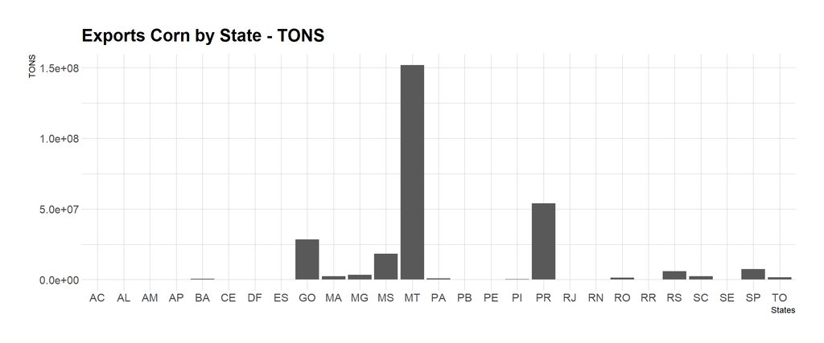

```r
corn_states_tons = data.frame(0)
for (i in 1:27) {
  corn_states_tons[i,] = export_br_state_tons[i,]
}
corn_states_tons = cbind(corn_states_tons, states)
colnames(corn_states_tons) = c("tons","state")

graph_corn_state_tons = ggplot(corn_states_tons, aes(x=states, y=tons))+
  geom_bar(stat = "identity")+
  theme_ipsum()+
  ggtitle("Exports Corn by State - TONS")+
  xlab("States")+
  ylab("TONS")
graph_corn_state_tons
```

The five most important states in terms of corn exports is Mato Grosso (MT), Paraná (PR), Goiás (GO), Mato Grosso do Sul (MS) and São Paulo (SP). The corn exports of MT is almost three times the exports of the second place, PR.

##### - Export Soybean_meal by state - TONS

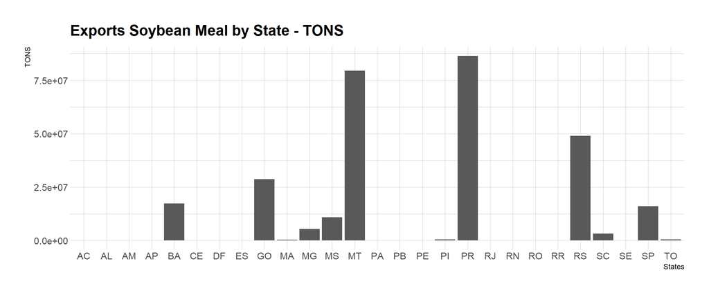

```r
soybean_meal_states_tons = data.frame(0)
for (i in 1:27) {
  soybean_meal_states_tons[i,] = export_br_state_tons[i+27,]
}
soybean_meal_states_tons = cbind(soybean_meal_states_tons, states)
colnames(soybean_meal_states_tons) = c("tons","state")

graph_soybean_meal_state_tons = ggplot(soybean_meal_states_tons, aes(x=states, y=tons))+
  geom_bar(stat = "identity")+
  theme_ipsum()+
  ggtitle("Exports Soybean Meal by State - TONS")+
  xlab("States")+
  ylab("TONS")
graph_soybean_meal_state_tons
```

The state that most export soybean meal are PR, MT, Rio Grande do Sul (RS), GO and Bahia (BA). MT and PR are the biggers states seller of soybean meal.

##### - Export Soybean_oil by state - TONS

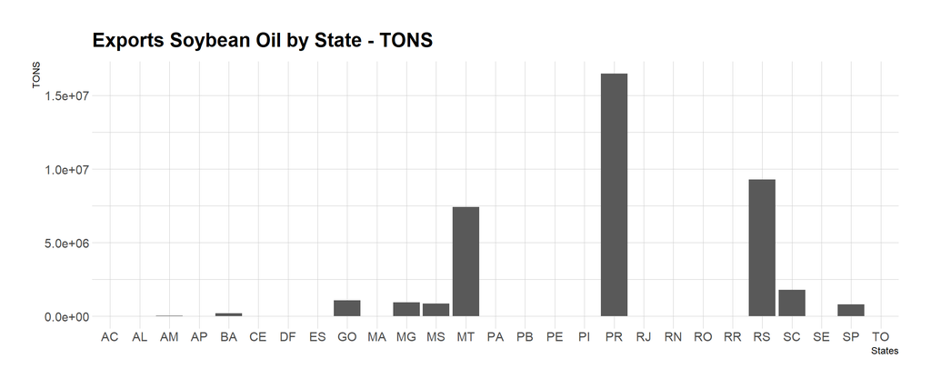

```r
soybean_oil_states_tons = data.frame(0)
for (i in 1:27) {
  soybean_oil_states_tons[i,] = export_br_state_tons[i+54,]
}
soybean_oil_states_tons = cbind(soybean_oil_states_tons, states)
colnames(soybean_oil_states_tons) = c("tons","state")

graph_soybean_oil_state_tons = ggplot(soybean_oil_states_tons, aes(x=states, y=tons))+
  geom_bar(stat = "identity")+
  theme_ipsum()+
  ggtitle("Exports Soybean Oil by State - TONS")+
  xlab("States")+
  ylab("TONS")
graph_soybean_oil_state_tons
```

The main states exports of soybean oil are: PR, RS, MT, Santa Catarina (SC) and GO.

##### - Export Soybeans by state - TONS

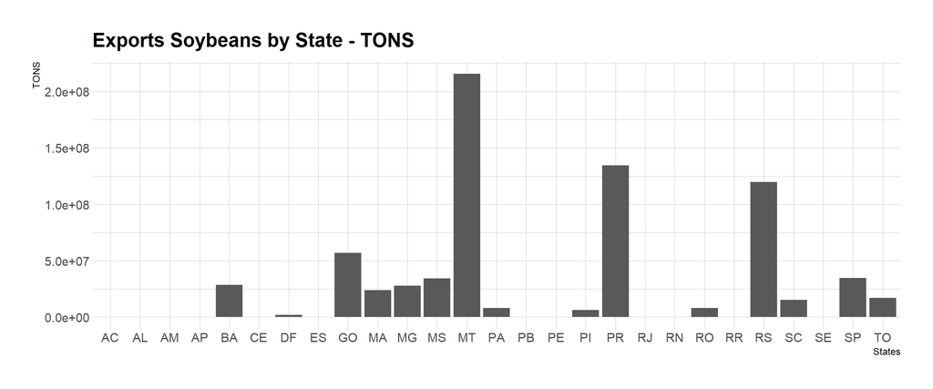

```r
soybeans_states_tons = data.frame(0)
for (i in 1:27) {
  soybeans_states_tons[i,] = export_br_state_tons[i+81,] ### Sempre somar mais 27
}
soybeans_states_tons = cbind(soybeans_states_tons, states)
colnames(soybeans_states_tons) = c("tons","state")

graph_soybeans_state_tons = ggplot(soybeans_states_tons, aes(x=states, y=tons))+
  geom_bar(stat = "identity")+
  theme_ipsum()+
  ggtitle("Exports Soybeans by State - TONS")+
  xlab("States")+
  ylab("TONS")
graph_soybeans_state_tons
```

The most important states in terms of soybeans exports are: MT, PR, RS, GO and SP.

##### - Export Sugar by state - TONS

[figure not shown]

```r
sugar_states_tons = data.frame(0)
for (i in 1:27) {
  sugar_states_tons[i,] = export_br_state_tons[i+27,] ### Sempre somar mais 27
}
sugar_states_tons = cbind(sugar_states_tons, states)
colnames(sugar_states_tons) = c("tons","state")

graph_sugar_state_tons = ggplot(sugar_states_tons, aes(x=states, y=tons))+
  geom_bar(stat = "identity")+
  theme_ipsum()+
  ggtitle("Exports Sugar by State - TONS")+
  xlab("States")+
  ylab("TONS")
graph_sugar_state_tons
```

##### - Export Wheat by state - TONS

[figure not shown]

```r
Wheat_states_tons = data.frame(0)
for (i in 1:27) {
  Wheat_states_tons[i,] = export_br_state_tons[i+108,] ### Sempre somar mais 27
}
Wheat_states_tons = cbind(Wheat_states_tons, states)
colnames(Wheat_states_tons) = c("tons","state")

graph_Wheat_state_tons = ggplot(Wheat_states_tons, aes(x=states, y=tons))+
  geom_bar(stat = "identity")+
  theme_ipsum()+
  ggtitle("Exports Wheat by State - TONS")+
  xlab("States")+
  ylab("TONS")
graph_Wheat_state_tons
```

##### - Exports all products in USD

```r
export_br_state_usd = data.frame(0)
for (i in 1:length(list_comex_br_state)) {
  export_br_state_usd[i,] = sum(list_comex_br_state[[i]]$usd)
}
```